# 12.9.2023DataBreachCleaningAnalysis

```python
import pandas as pd
import numpy as np
import matplotlib.pyplot as plt
import seaborn as sns

import string
import nltk
from nltk.corpus import stopwords
from nltk import sent_tokenize
from nltk.tokenize import word_tokenize
from nltk.stem import WordNetLemmatizer
from nltk.tokenize import word_tokenize
from wordcloud import WordCloud, STOPWORDS
```

### Text Preprocessing

```python
import string
import nltk
from nltk.corpus import stopwords
from nltk import sent_tokenize
from nltk.tokenize import word_tokenize
from nltk.stem import WordNetLemmatizer
from nltk.tokenize import word_tokenize
from nltk.stem import WordNetLemmatizer

def preprocess(text):
    # split into sentences
    sentences = sent_tokenize(text)

    # split into words
    tokens = word_tokenize(text)

    # convert to lower case
    tokens = [w.lower() for w in tokens]

    # remove punctuation from each word
    table = str.maketrans('', '', string.punctuation)
    stripped = [w.translate(table) for w in tokens]

    # remove remaining tokens that are not alphabetic
    words = [word for word in stripped if word.isalpha()]

    # filter out stop words
    stop_words = set(stopwords.words('english'))
    words = [w for w in words if not w in stop_words]

    # Lemmatize the tokens
    lemmatizer = WordNetLemmatizer()
    lemmatized_tokens = [lemmatizer.lemmatize(word) for word in words]

    # Join the tokens back into a string
    processed_text = ' '.join(lemmatized_tokens)
    return processed_text
```

### Import databreaches Excel file

```python
df = pd.read_csv('cleanausdatabreach2018-23.csv', encoding='latin1')
df.info()
```

```
<class 'pandas.core.frame.DataFrame'>
RangeIndex: 101 entries, 0 to 100
Data columns (total 30 columns):
 #   Column                     Non-Null Count  Dtype
---  ------                     --------------  -----
 0   Name                       101 non-null    object
 1   CountryOfNotification      101 non-null    object
 2   DataBreachSource           101 non-null    object
 3   IncidentDescription        16 non-null     object
 4   NumberOfAusPeopleAffected  42 non-null     object
 5   IncidentDay                84 non-null     float64
 6   IncidentMonth              99 non-null     float64
 7   IncidentYear               101 non-null    int64
 8   IncidentDate               84 non-null     object
 9   NotificationDate           101 non-null    object
```

[output cut: 22 more lines]

### Drop one record

```python
df[df['Name']=='Department of Foreign Affairs and Trade']
```

|  | Name | CountryOfNotification | DataBreachSource | IncidentDescription | NumberOfAusPeopleAffected | IncidentDay | IncidentMonth | IncidentYear | IncidentDate | NotificationDate | ... | Apology | Compensation | ResponsiveAction | ValueCommitment | CustomerFocus | OpenDisclosure | CustomerAdvice | ExtraMediaURL1 | ExtraMediaURL2 | Notes |
| --- | --- | --- | --- | --- | --- | --- | --- | --- | --- | --- | --- | --- | --- | --- | --- | --- | --- | --- | --- | --- | --- |
| 18 | Department of Foreign Affairs and Trade | Australia | Human error | NaN | 1000 | 30.0 | 9.0 | 2020 | 30/09/2020 | 30/09/2020 | ... | 1.0 | NaN | NaN | NaN | 3.0 | 2.0 | NaN | NaN | NaN | NaN |

1 rows × 30 columns

```python
df.drop(18, inplace=True)
```

```python
df = df.reset_index(drop=True)
df.info()
```

```
<class 'pandas.core.frame.DataFrame'>
RangeIndex: 100 entries, 0 to 99
Data columns (total 30 columns):
 #   Column                     Non-Null Count  Dtype
---  ------                     --------------  -----
 0   Name                       100 non-null    object
 1   CountryOfNotification      100 non-null    object
 2   DataBreachSource           100 non-null    object
 3   IncidentDescription        16 non-null     object
 4   NumberOfAusPeopleAffected  41 non-null     object
 5   IncidentDay                83 non-null     float64
 6   IncidentMonth              98 non-null     float64
 7   IncidentYear               100 non-null    int64
 8   IncidentDate               83 non-null     object
 9   NotificationDate           100 non-null    object
```

[output cut: 22 more lines]

### Incident Date column

```python
incident_date = df['IncidentDate']
incident_date
```

```
0     23/05/2018
1     24/05/2019
2            NaN
3     22/05/2019
4     24/07/2019
         ...
95    27/07/2020
96           NaN
97    17/05/2018
98     1/06/2023
99           NaN
Name: IncidentDate, Length: 100, dtype: object
```

```python
df.drop(columns=['IncidentDate'], inplace=True)
```

```python
df.head()
```

|  | Name | CountryOfNotification | DataBreachSource | IncidentDescription | NumberOfAusPeopleAffected | IncidentDay | IncidentMonth | IncidentYear | NotificationDate | NotificationURL | ... | Apology | Compensation | ResponsiveAction | ValueCommitment | CustomerFocus | OpenDisclosure | CustomerAdvice | ExtraMediaURL1 | ExtraMediaURL2 | Notes |
| --- | --- | --- | --- | --- | --- | --- | --- | --- | --- | --- | --- | --- | --- | --- | --- | --- | --- | --- | --- | --- | --- |
| 0 | PageUp People | Australia | Malicious or criminal attack | NaN | NaN | 23.0 | 5.0 | 2018 | 05/06/2018 | https://web.archive.org/web/20190813054217/htt... | ... | 5.0 | NaN | 3.0 | 1.0 | NaN | NaN | 4.0 | NaN | NaN | Different types of data compromised by employe... |
| 1 | Canva | Australia | Malicious or criminal attack | NaN | 139000000 | 24.0 | 5.0 | 2019 | 01/06/2019 | https://www.canva.com/help/incident-may24/ | ... | 7.0 | 6.0 | 2.0 | 4.0 | 8.0 | 3.0 | 5.0 | NaN | NaN | NaN |
| 2 | Australian National University | Australia | Malicious or criminal attack | NaN | NaN | NaN | 11.0 | 2018 | 04/06/2019 | https://www.anu.edu.au/news/all-news/message-f... | ... | 1.0 | NaN | 3.0 | 5.0 | NaN | 4.0 | 6.0 | NaN | NaN | NaN |
| 3 | Australian Catholic University | Australia | Malicious or criminal attack | NaN | NaN | 22.0 | 5.0 | 2019 | 17/06/2019 | https://www.acu.edu.au/about-acu/news/2019/jun... | ... | 2.0 | NaN | 4.0 | 6.0 | NaN | 3.0 | 5.0 | NaN | NaN | NaN |
| 4 | NAB | Australia | Human error | NaN | 13000 | 24.0 | 7.0 | 2019 | 26/07/2019 | https://news.nab.com.au/news/nab-apologises-to... | ... | 5.0 | 7.0 | 2.0 | 4.0 | 6.0 | 3.0 | 8.0 | NaN | NaN | NaN |

5 rows × 29 columns

```python
df.tail()
```

|  | Name | CountryOfNotification | DataBreachSource | IncidentDescription | NumberOfAusPeopleAffected | IncidentDay | IncidentMonth | IncidentYear | NotificationDate | NotificationURL | ... | Apology | Compensation | ResponsiveAction | ValueCommitment | CustomerFocus | OpenDisclosure | CustomerAdvice | ExtraMediaURL1 | ExtraMediaURL2 | Notes |
| --- | --- | --- | --- | --- | --- | --- | --- | --- | --- | --- | --- | --- | --- | --- | --- | --- | --- | --- | --- | --- | --- |
| 95 | ProctorU | Global | Malicious or criminal attack | NaN | NaN | 27.0 | 7.0 | 2020 | 07/08/2020 | https://web.archive.org/web/20200807192353/htt... | ... | NaN | NaN | 3.0 | 4.0 | NaN | NaN | NaN | http://honisoit.com/2020/08/hackers-publish-au... | https://www.proctoru.com/security-update | Media reports impacts on Australian universities |
| 96 | City of Port Phillip council | Australia | Human error | Personal information was accidently disclosed ... | NaN | NaN | 3.0 | 2020 | 28/10/2020 | https://web.archive.org/web/20201124124412/htt... | ... | 4.0 | NaN | 3.0 | 5.0 | NaN | 2.0 | 6.0 | NaN | NaN | NaN |
| 97 | RCR Tomlinson | Australia | Malicious or criminal attack | NaN | NaN | 17.0 | 5.0 | 2018 | 04/07/2018 | https://web.archive.org.au/awa/20190509041051m... | ... | 5.0 | 7.0 | 3.0 | 1.0 | 9.0 | 8.0 | 6.0 | NaN | NaN | NaN |
| 98 | Aristocrat | Australia | Malicious or criminal attack | hacker exploited a newly identified (zero day)... | NaN | 1.0 | 6.0 | 2023 | 04/08/2023 | https://www.aristocrat.com/statement-on-cyber-... | ... | NaN | 4.0 | 3.0 | 2.0 | NaN | NaN | NaN | NaN | NaN | NaN |
| 99 | Appen | Australia | Malicious or criminal attack | Malicious actors hacked the systems of the thi... | NaN | NaN | 7.0 | 2020 | 30/07/2020 | https://yourir.info/resources/396cdf0a32f7cb50... | ... | NaN | NaN | 3.0 | 4.0 | NaN | NaN | NaN | NaN | NaN | NaN |

5 rows × 29 columns

### EDA

```python
#function to display values on barcharts
def show_values(axs, orient="v", space=.01):
    def _single(ax):
        if orient == "v":
            for p in ax.patches:
                _x = p.get_x() + p.get_width() / 2
                _y = p.get_y() + p.get_height() + (p.get_height()*0.01)
                value = '{:.0f}'.format(p.get_height(), fontsize=14)
                ax.text(_x, _y, value, ha="center", fontsize=12)
        elif orient == "h":
            for p in ax.patches:
                _x = p.get_x() + p.get_width() + float(space)
                _y = p.get_y() + p.get_height() - (p.get_height()*0.1)
                value = '{:.0f}'.format(p.get_width(), fontsize=14)
                ax.text(_x, _y, value, ha="left", fontsize=12)

    if isinstance(axs, np.ndarray):
        for idx, ax in np.ndenumerate(axs):
            _single(ax)
    else:
        _single(axs)
```

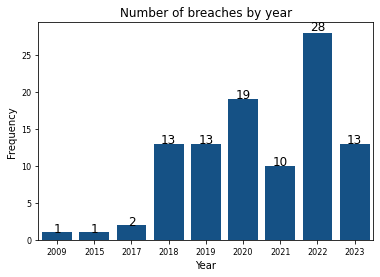

```python
import seaborn as sns

# Calculate value counts
value_counts = df['IncidentYear'].value_counts().sort_index()

# Create bar plot
p = sns.barplot(x=value_counts.index, y=value_counts.values, color='#035397')
show_values(p)
plt.xlabel('Year')
plt.ylabel('Frequency')
plt.title('Number of breaches by year')
plt.xticks(fontsize=8)
plt.yticks(fontsize=8)
plt.show()
```

### Percentages of each characteristics

```python
df['DetailedExplanation'].notna().value_counts().sort_index()
```

```
False     4
True     96
Name: DetailedExplanation, dtype: int64
```

```python
df['Whitewashing'].notna().value_counts(normalize=True).sort_index()[1]
```

```
0.48
```

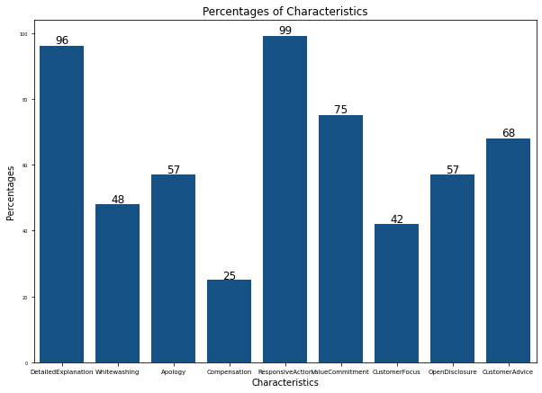

```python
boolean_col = ['DetailedExplanation', 'Whitewashing', 'Apology',
               'Compensation', 'ResponsiveAction', 'ValueCommitment',
                'CustomerFocus', 'OpenDisclosure', 'CustomerAdvice']

values = []
for col in boolean_col:
    pct = df[col].notna().value_counts(normalize=True).sort_index()[1] * 100
    values.append(pct)

# Create bar plot
plt.figure(figsize=(10,7))
p = sns.barplot(x=boolean_col, y=values, color='#035397')
show_values(p)
plt.xlabel('Characteristics')
plt.ylabel('Percentages')
plt.title('Percentages of Characteristics')
plt.xticks(fontsize=7)
plt.yticks(fontsize=5)
plt.show()
```

### Percentages of each characteristics by order

```python
df['DetailedExplanation'].value_counts(normalize=True, dropna=False).sort_index() * 100
```

```
1.0    78.0
2.0    12.0
3.0     3.0
4.0     3.0
NaN     4.0
Name: DetailedExplanation, dtype: float64
```

```python
df['Whitewashing'].value_counts(normalize=True, dropna=False).sort_index() * 100
```

```
1.0     4.0
2.0     9.0
3.0     9.0
4.0    14.0
5.0     7.0
6.0     4.0
7.0     1.0
NaN    52.0
Name: Whitewashing, dtype: float64
```

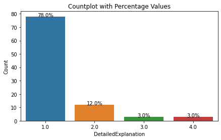

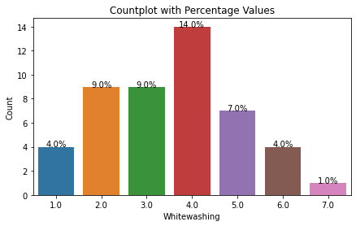

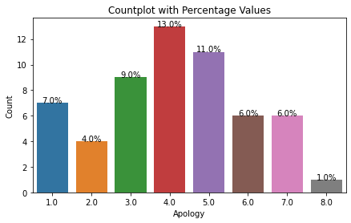

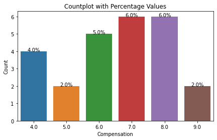

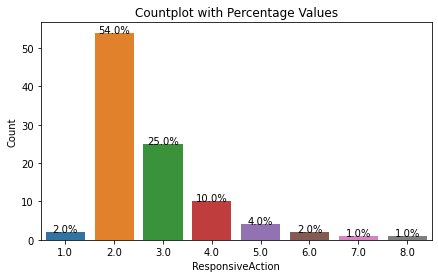

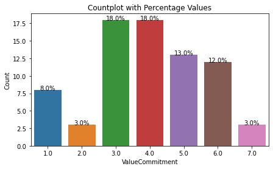

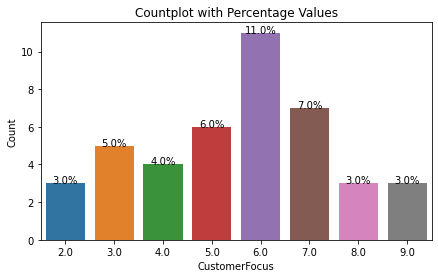

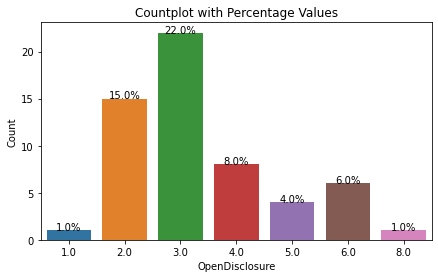

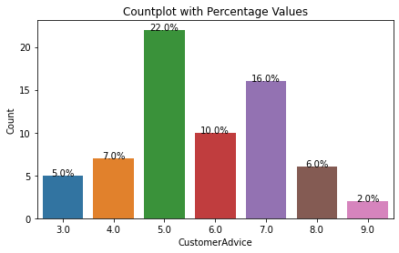

```python
for col in boolean_col:

    # 3. Create a countplot
    plt.figure(figsize=(7, 4))

    # 4. Calculate percentage values for each category
    total_count = len(df)
    ax = sns.countplot(x=col, data=df)

    # 5. Annotate the plot with percentage values
    for p in ax.patches:
        height = p.get_height()
        ax.annotate(f'{height/total_count:.1%}', (p.get_x() + p.get_width() / 2., height), ha='center')

    plt.xlabel(col)
    plt.ylabel('Count')
    plt.title('Countplot with Percentage Values')
    plt.show()
```

### Count of each characteristics by order

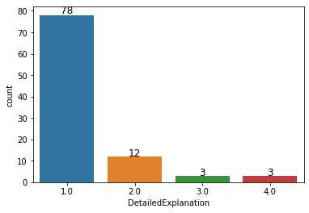

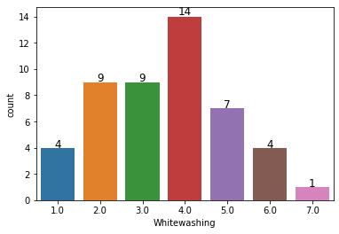

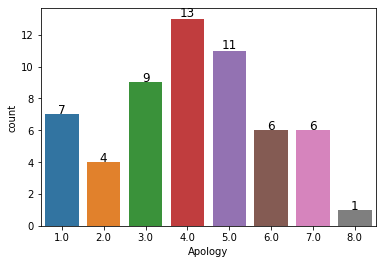

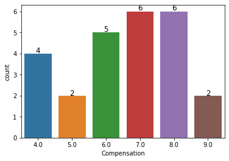

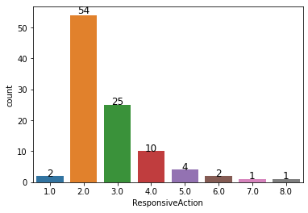

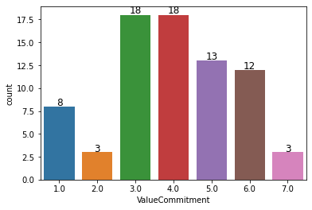

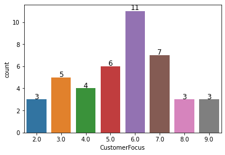

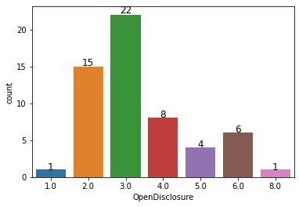

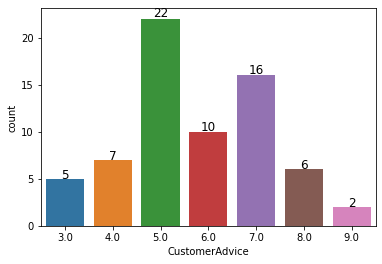

```python
# Create bar plot for each characteristic
for col in boolean_col:
    p = sns.countplot(data=df, x=col)
    show_values(p)
    plt.show()
```

There are 22 statements with Customer Advice provided in the 5th order of the statement.

```python
df['Whitewashing'].notna().value_counts()
```

```
False    52
True     48
Name: Whitewashing, dtype: int64
```

```python
df['Whitewashing'][2]
```

```
7.0
```

```python
np.isnan(df['Whitewashing'][2]) # False: Has a value, True: Doesn't have a value
```

```
False
```

### Response Grouping

```python
df.head()
```

|  | Name | CountryOfNotification | DataBreachSource | IncidentDescription | NumberOfAusPeopleAffected | IncidentDay | IncidentMonth | IncidentYear | NotificationDate | NotificationURL | ... | Apology | Compensation | ResponsiveAction | ValueCommitment | CustomerFocus | OpenDisclosure | CustomerAdvice | ExtraMediaURL1 | ExtraMediaURL2 | Notes |
| --- | --- | --- | --- | --- | --- | --- | --- | --- | --- | --- | --- | --- | --- | --- | --- | --- | --- | --- | --- | --- | --- |
| 0 | PageUp People | Australia | Malicious or criminal attack | NaN | NaN | 23.0 | 5.0 | 2018 | 05/06/2018 | https://web.archive.org/web/20190813054217/htt... | ... | 5.0 | NaN | 3.0 | 1.0 | NaN | NaN | 4.0 | NaN | NaN | Different types of data compromised by employe... |
| 1 | Canva | Australia | Malicious or criminal attack | NaN | 139000000 | 24.0 | 5.0 | 2019 | 01/06/2019 | https://www.canva.com/help/incident-may24/ | ... | 7.0 | 6.0 | 2.0 | 4.0 | 8.0 | 3.0 | 5.0 | NaN | NaN | NaN |
| 2 | Australian National University | Australia | Malicious or criminal attack | NaN | NaN | NaN | 11.0 | 2018 | 04/06/2019 | https://www.anu.edu.au/news/all-news/message-f... | ... | 1.0 | NaN | 3.0 | 5.0 | NaN | 4.0 | 6.0 | NaN | NaN | NaN |
| 3 | Australian Catholic University | Australia | Malicious or criminal attack | NaN | NaN | 22.0 | 5.0 | 2019 | 17/06/2019 | https://www.acu.edu.au/about-acu/news/2019/jun... | ... | 2.0 | NaN | 4.0 | 6.0 | NaN | 3.0 | 5.0 | NaN | NaN | NaN |
| 4 | NAB | Australia | Human error | NaN | 13000 | 24.0 | 7.0 | 2019 | 26/07/2019 | https://news.nab.com.au/news/nab-apologises-to... | ... | 5.0 | 7.0 | 2.0 | 4.0 | 6.0 | 3.0 | 8.0 | NaN | NaN | NaN |

5 rows × 29 columns

```python
# FullTransparency
def type1(row):

    if (np.isnan(row['DetailedExplanation']) == False) & (np.isnan(row['Whitewashing']) == True) & (np.isnan(row['ResponsiveAction']) == False) & (np.isnan(row['ValueCommitment']) == False) & (np.isnan(row['OpenDisclosure']) == False):
        return 1
    else:
        return 0

# Apply the custom function to create a new column
df['FullTransparency'] = df.apply(type1, axis=1)
```

```python
# df[df['FullTransparency']==1].iloc[:,7:-1]
```

```python
# 0 True, 1 False
# Guarded
def type2(row):

    if (np.isnan(row['DetailedExplanation']) == True) & (np.isnan(row['Whitewashing']) == False) & (np.isnan(row['ResponsiveAction']) == False) & (np.isnan(row['ValueCommitment']) == False)  & (np.isnan(row['OpenDisclosure']) == True):
        return 1
    else:
        return 0

# Apply the custom function to create a new column
df['Guarded'] = df.apply(type2, axis=1)
```

```python
# Opacity
def type3(row):

    if (np.isnan(row['DetailedExplanation']) == True) & (np.isnan(row['Whitewashing']) == False) & (np.isnan(row['ResponsiveAction']) == False) & (np.isnan(row['ValueCommitment']) == True)  & (np.isnan(row['OpenDisclosure']) == True):
        return 1
    else:
        return 0

# Apply the custom function to create a new column
df['Opacity'] = df.apply(type3, axis=1)
```

```python
# CustomerInterest
def type4(row):

    if (np.isnan(row['Apology']) == False) & (np.isnan(row['Compensation']) == False) & (np.isnan(row['CustomerFocus']) == False) & (np.isnan(row['CustomerAdvice']) == False):
        return 1
    else:
        return 0

# Apply the custom function to create a new column
df['CustomerInterest'] = df.apply(type4, axis=1)
```

```python
# BalancedInterest
def type5(row):

    if (np.isnan(row['Apology']) == False) & (np.isnan(row['Compensation']) == True):
        return 1
    else:
        return 0

# Apply the custom function to create a new column
df['BalancedInterest'] = df.apply(type5, axis=1)
```

```python
# CompanyInterest
def type6(row):

    if (np.isnan(row['Apology']) == True) & (np.isnan(row['Compensation']) == True) & (np.isnan(row['CustomerFocus']) == True) & (np.isnan(row['CustomerAdvice']) == True):
        return 1
    else:
        return 0

# Apply the custom function to create a new column
df['CompanyInterest'] = df.apply(type6, axis=1)
```

```python
df.iloc[:5,-6:]
```

|  | FullTransparency | Guarded | Opacity | CustomerInterest | BalancedInterest | CompanyInterest |
| --- | --- | --- | --- | --- | --- | --- |
| 0 | 0 | 0 | 0 | 0 | 1 | 0 |
| 1 | 1 | 0 | 0 | 1 | 0 | 0 |
| 2 | 0 | 0 | 0 | 0 | 1 | 0 |
| 3 | 1 | 0 | 0 | 0 | 1 | 0 |
| 4 | 1 | 0 | 0 | 1 | 0 | 0 |

### Percentages of each response types

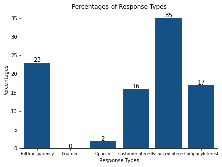

```python
response_col = ['FullTransparency', 'Guarded', 'Opacity',
               'CustomerInterest', 'BalancedInterest', 'CompanyInterest']

values_pct = []
for col in response_col:
    # If there is only one value
    if len(df[col].value_counts(normalize=True)) == 1:
        values_pct.append(0)

    else:
        pct = df[col].value_counts(normalize=True)[1]*100

        values_pct.append(pct)

# Create bar plot

plt.figure(figsize=(7,5))
p = sns.barplot(x=response_col, y=values_pct, color='#035397')
show_values(p)
plt.xlabel('Response Types')
plt.ylabel('Percentages')
plt.title('Percentages of Response Types')
plt.xticks(fontsize=8)
plt.yticks(fontsize=10)
plt.show()
```

```python
df['BalancedInterest'].value_counts(normalize=True)[1]*100
```

```
35.0
```

### Creating the label

```python
df[response_col]
```

|  | FullTransparency | Guarded | Opacity | CustomerInterest | BalancedInterest | CompanyInterest |
| --- | --- | --- | --- | --- | --- | --- |
| 0 | 0 | 0 | 0 | 0 | 1 | 0 |
| 1 | 1 | 0 | 0 | 1 | 0 | 0 |
| 2 | 0 | 0 | 0 | 0 | 1 | 0 |
| 3 | 1 | 0 | 0 | 0 | 1 | 0 |
| 4 | 1 | 0 | 0 | 1 | 0 | 0 |
| ... | ... | ... | ... | ... | ... | ... |
| 95 | 0 | 0 | 0 | 0 | 0 | 1 |
| 96 | 1 | 0 | 0 | 0 | 1 | 0 |
| 97 | 0 | 0 | 0 | 1 | 0 | 0 |
| 98 | 0 | 0 | 0 | 0 | 0 | 0 |
| 99 | 0 | 0 | 0 | 0 | 0 | 1 |

100 rows × 6 columns

```python
# Use np.where to check conditions and assign values
df['LevelOfDetail'] = np.where(df['FullTransparency'] == 1, 1,
               np.where(df['Guarded'] == 1, 2,
                 np.where(df['Opacity'] == 1, 3, 0)))
```

```python
df['LevelOfDetail'].value_counts()
```

```
0    75
1    23
3     2
Name: LevelOfDetail, dtype: int64
```

##### Results

- 23 counts of FullTransparency, 2 counts of Opacity
- 75 statements can't be categorised into any two of these notification types

```python
df[df['Opacity'] == 1]
```

|  | Name | CountryOfNotification | DataBreachSource | IncidentDescription | NumberOfAusPeopleAffected | IncidentDay | IncidentMonth | IncidentYear | NotificationDate | NotificationURL | ... | ExtraMediaURL1 | ExtraMediaURL2 | Notes | FullTransparency | Guarded | Opacity | CustomerInterest | BalancedInterest | CompanyInterest | LevelOfDetail |
| --- | --- | --- | --- | --- | --- | --- | --- | --- | --- | --- | --- | --- | --- | --- | --- | --- | --- | --- | --- | --- | --- |
| 20 | Nitro Software | Australia | Malicious or criminal attack | NaN | NaN | 30.0 | 9.0 | 2020 | 21/10/2020 | https://ir.gonitro.com/Investor-Centre/?page=a... | ... | https://www.gonitro.com/security/updates#secur... | NaN | Notable case: ASX annoucenment lacks details, ... | 0 | 0 | 1 | 0 | 0 | 1 | 3 |
| 83 | Austal | Australia | Malicious or criminal attack | NaN | NaN | 1.0 | 11.0 | 2018 | 01/11/2018 | https://announcements.asx.com.au/asxpdf/201811... | ... | NaN | NaN | NaN | 0 | 0 | 1 | 0 | 0 | 1 | 3 |

2 rows × 36 columns

```python
# Use np.where to check conditions and assign values
df['BenefitParty'] = np.where(df['CustomerInterest'] == 1, 1,
               np.where(df['BalancedInterest'] == 1, 2,
                 np.where(df['CompanyInterest'] == 1, 3, 0)))
```

```python
df['BenefitParty'].value_counts()
```

```
2    35
0    32
3    17
1    16
Name: BenefitParty, dtype: int64
```

##### Results

- 16 counts of CustomerInterest, 35 counts of Balanced, 17 counts of CompanyInterest
- 32 statements can't be categorised into any of these 3 types

```python
df[['Name', 'LevelOfDetail','BenefitParty']]
```

|  | Name | LevelOfDetail | BenefitParty |
| --- | --- | --- | --- |
| 0 | PageUp People | 0 | 2 |
| 1 | Canva | 1 | 1 |
| 2 | Australian National University | 0 | 2 |
| 3 | Australian Catholic University | 1 | 2 |
| 4 | NAB | 1 | 1 |
| ... | ... | ... | ... |
| 95 | ProctorU | 0 | 3 |
| 96 | City of Port Phillip council | 1 | 2 |
| 97 | RCR Tomlinson | 0 | 1 |
| 98 | Aristocrat | 0 | 0 |
| 99 | Appen | 0 | 3 |

100 rows × 3 columns

### Check distinct combinations of notification types

```python
from itertools import product

# Find different combinations of 'Column1' and 'Column2' values
combinations = list(product(df['LevelOfDetail'], df['BenefitParty']))

# print(combinations)
# Convert the list of tuples into a set to remove duplicates
distinct_tuples = set(combinations)

# If you need the distinct tuples back in a list format, you can convert them back to a list
distinct_tuples_list = list(distinct_tuples)

# Print the distinct tuples
print("Distinct Tuples:")
for tuple_value in distinct_tuples_list:
    print(tuple_value)
```

```
Distinct Tuples:
(0, 1)
(1, 2)
(0, 0)
(3, 1)
(1, 1)
(0, 3)
(3, 0)
(0, 2)
(3, 3)
(1, 0)
(3, 2)
(1, 3)
```

There are twelve combinations of responses classes.

```python
# Convert the list of lists into a set to remove duplicates
# Convert the list of lists into a set of tuples
distinct_set = {tuple(sorted(lst)) for lst in distinct_tuples_list}

# If you need the distinct lists back in a list format, you can convert them back to a list
distinct_list = [list(tpl) for tpl in distinct_set]

distinct_list
```

```
[[0, 1], [1, 2], [0, 0], [1, 1], [0, 3], [2, 3], [0, 2], [3, 3], [1, 3]]
```

There are nine distinct combinations of responses classes (without duplicates).

### Class Labelling

```python
# Check statistics
```

```python
df.head()
```

|  | Name | CountryOfNotification | DataBreachSource | IncidentDescription | NumberOfAusPeopleAffected | IncidentDay | IncidentMonth | IncidentYear | NotificationDate | NotificationURL | ... | ExtraMediaURL2 | Notes | FullTransparency | Guarded | Opacity | CustomerInterest | BalancedInterest | CompanyInterest | LevelOfDetail | BenefitParty |
| --- | --- | --- | --- | --- | --- | --- | --- | --- | --- | --- | --- | --- | --- | --- | --- | --- | --- | --- | --- | --- | --- |
| 0 | PageUp People | Australia | Malicious or criminal attack | NaN | NaN | 23.0 | 5.0 | 2018 | 05/06/2018 | https://web.archive.org/web/20190813054217/htt... | ... | NaN | Different types of data compromised by employe... | 0 | 0 | 0 | 0 | 1 | 0 | 0 | 2 |
| 1 | Canva | Australia | Malicious or criminal attack | NaN | 139000000 | 24.0 | 5.0 | 2019 | 01/06/2019 | https://www.canva.com/help/incident-may24/ | ... | NaN | NaN | 1 | 0 | 0 | 1 | 0 | 0 | 1 | 1 |
| 2 | Australian National University | Australia | Malicious or criminal attack | NaN | NaN | NaN | 11.0 | 2018 | 04/06/2019 | https://www.anu.edu.au/news/all-news/message-f... | ... | NaN | NaN | 0 | 0 | 0 | 0 | 1 | 0 | 0 | 2 |
| 3 | Australian Catholic University | Australia | Malicious or criminal attack | NaN | NaN | 22.0 | 5.0 | 2019 | 17/06/2019 | https://www.acu.edu.au/about-acu/news/2019/jun... | ... | NaN | NaN | 1 | 0 | 0 | 0 | 1 | 0 | 1 | 2 |
| 4 | NAB | Australia | Human error | NaN | 13000 | 24.0 | 7.0 | 2019 | 26/07/2019 | https://news.nab.com.au/news/nab-apologises-to... | ... | NaN | NaN | 1 | 0 | 0 | 1 | 0 | 0 | 1 | 1 |

5 rows × 37 columns

```python
boolean_col = ['DetailedExplanation', 'Whitewashing', 'Apology',
               'Compensation', 'ResponsiveAction', 'ValueCommitment',
                'CustomerFocus', 'OpenDisclosure', 'CustomerAdvice']

response_col = ['FullTransparency', 'Guarded', 'Opacity',
               'CustomerInterest', 'BalancedInterest', 'CompanyInterest']

class_col = ['LevelOfDetail', 'BenefitParty']
```

```python
for col in response_col:
    print(col, ": ")
    print(df[col].value_counts(normalize=True))
```

```
FullTransparency :
0    0.77
1    0.23
Name: FullTransparency, dtype: float64
Guarded :
0    1.0
Name: Guarded, dtype: float64
Opacity :
0    0.98
1    0.02
Name: Opacity, dtype: float64
CustomerInterest :
0    0.84
1    0.16
Name: CustomerInterest, dtype: float64
BalancedInterest :
0    0.65
1    0.35
Name: BalancedInterest, dtype: float64
CompanyInterest :
0    0.83
1    0.17
Name: CompanyInterest, dtype: float64
```

##### Results for 100 records

- 23% or 23 of statements: FullTransparency
- 0%: Guarded
- 2%: Opacity
- 16% CustomerInterest
- 35% BalancedInterest
- 17% CompanyInterest

```python
# Get records where LevelOfDetail = 0
test = df[boolean_col][df['LevelOfDetail'] == 0]
```

```python
test.info()
```

```
<class 'pandas.core.frame.DataFrame'>
Int64Index: 75 entries, 0 to 99
Data columns (total 9 columns):
 #   Column               Non-Null Count  Dtype
---  ------               --------------  -----
 0   DetailedExplanation  73 non-null     float64
 1   Whitewashing         46 non-null     float64
 2   Apology              37 non-null     float64
 3   Compensation         13 non-null     float64
 4   ResponsiveAction     74 non-null     float64
 5   ValueCommitment      52 non-null     float64
 6   CustomerFocus        32 non-null     float64
 7   OpenDisclosure       34 non-null     float64
 8   CustomerAdvice       48 non-null     float64
dtypes: float64(9)
memory usage: 5.9 KB
```

```python
test.head()
```

|  | DetailedExplanation | Whitewashing | Apology | Compensation | ResponsiveAction | ValueCommitment | CustomerFocus | OpenDisclosure | CustomerAdvice |
| --- | --- | --- | --- | --- | --- | --- | --- | --- | --- |
| 0 | 2.0 | NaN | 5.0 | NaN | 3.0 | 1.0 | NaN | NaN | 4.0 |
| 2 | 2.0 | 7.0 | 1.0 | NaN | 3.0 | 5.0 | NaN | 4.0 | 6.0 |
| 6 | 1.0 | 4.0 | 5.0 | NaN | 6.0 | 3.0 | NaN | 2.0 | 7.0 |
| 7 | 1.0 | 5.0 | 3.0 | NaN | 2.0 | 4.0 | NaN | NaN | 6.0 |
| 8 | 1.0 | 4.0 | NaN | NaN | 2.0 | 3.0 | NaN | NaN | 5.0 |

```python
test.tail()
```

|  | DetailedExplanation | Whitewashing | Apology | Compensation | ResponsiveAction | ValueCommitment | CustomerFocus | OpenDisclosure | CustomerAdvice |
| --- | --- | --- | --- | --- | --- | --- | --- | --- | --- |
| 94 | 1.0 | 3.0 | 4.0 | 9.0 | 2.0 | 5.0 | 7.0 | 6.0 | 8.0 |
| 95 | 1.0 | 2.0 | NaN | NaN | 3.0 | 4.0 | NaN | NaN | NaN |
| 97 | 2.0 | 4.0 | 5.0 | 7.0 | 3.0 | 1.0 | 9.0 | 8.0 | 6.0 |
| 98 | 1.0 | NaN | NaN | 4.0 | 3.0 | 2.0 | NaN | NaN | NaN |
| 99 | 2.0 | 1.0 | NaN | NaN | 3.0 | 4.0 | NaN | NaN | NaN |

- For each statement above, I need to perform "fuzzy" matchching to categorise them into one of three types: FullTranparency, Guarded, or Opacity.
- 5 characteristics are considered when coding this: Detailed explanation, Whitewashing, Responsive action, Value commitment, and Open disclosure

```python
for col in boolean_col:
    print(col, ": ")
    print(test[col].value_counts(dropna=False).sort_index())
```

```
DetailedExplanation :
1.0    58
2.0    10
3.0     3
4.0     2
NaN     2
Name: DetailedExplanation, dtype: int64
Whitewashing :
1.0     3
2.0     8
3.0     9
4.0    14
5.0     7
6.0     4
7.0     1
NaN    29
Name: Whitewashing, dtype: int64
Apology :
1.0     6
2.0     3
3.0     6
4.0     6
5.0     7
6.0     4
7.0     4
8.0     1
NaN    38
Name: Apology, dtype: int64
Compensation :
4.0     2
6.0     4
7.0     3
8.0     2
9.0     2
NaN    62
Name: Compensation, dtype: int64
ResponsiveAction :
1.0     1
2.0    41
3.0    18
```

[output cut: 32 more lines]

```
5.0     2
6.0     4
8.0     1
NaN    41
Name: OpenDisclosure, dtype: int64
CustomerAdvice :
3.0     5
4.0     6
5.0    15
6.0     6
7.0    10
8.0     4
9.0     2
NaN    27
Name: CustomerAdvice, dtype: int64
```

```python
test['Manual'] = 0
```

#### Possible categorisation

- 7 records with all characteristics present for FullTransparency type except for Whitewashing will be categorised as "Guarded" as Whitewashing and Open Disclosure are "Y" in Guarded type.
- For the remaining 68 records where there is at least one values with null values, we will categorised based on the following criteria: Guarded and Opacity will be transformed into a formula. Then each statement will be transformed into a formula based on their characteristics. If the number of characteristics is closer to Guarded, it will be categorised as Guarded, else Opacity.

If the number of match the same, we will check further.

##### 7 records without null values

```python
# Check which rows have no null values
test[test.notna().all(axis=1)] # 7 records
```

|  | DetailedExplanation | Whitewashing | Apology | Compensation | ResponsiveAction | ValueCommitment | CustomerFocus | OpenDisclosure | CustomerAdvice | Manual |
| --- | --- | --- | --- | --- | --- | --- | --- | --- | --- | --- |
| 49 | 1.0 | 4.0 | 6.0 | 9.0 | 2.0 | 5.0 | 7.0 | 3.0 | 8.0 | 0 |
| 57 | 1.0 | 5.0 | 8.0 | 6.0 | 3.0 | 2.0 | 7.0 | 4.0 | 9.0 | 0 |
| 78 | 3.0 | 5.0 | 6.0 | 7.0 | 8.0 | 1.0 | 2.0 | 4.0 | 9.0 | 0 |
| 79 | 4.0 | 1.0 | 2.0 | 8.0 | 5.0 | 3.0 | 9.0 | 6.0 | 7.0 | 0 |
| 87 | 1.0 | 5.0 | 3.0 | 8.0 | 2.0 | 4.0 | 9.0 | 6.0 | 7.0 | 0 |
| 94 | 1.0 | 3.0 | 4.0 | 9.0 | 2.0 | 5.0 | 7.0 | 6.0 | 8.0 | 0 |
| 97 | 2.0 | 4.0 | 5.0 | 7.0 | 3.0 | 1.0 | 9.0 | 8.0 | 6.0 | 0 |

```python
test[test.notna().all(axis=1)].index
```

```
Int64Index([49, 57, 78, 79, 87, 94, 97], dtype='int64')
```

```python
test.loc[test.index.isin(test[test.notna().all(axis=1)].index), 'Manual'] = 2
```

```python
test['Manual'].value_counts(dropna=False)
```

```
0    68
2     7
Name: Manual, dtype: int64
```

##### 68 records with at least 1 null values

```python
# Check which rows have at least 1 null values
test[test.isna().any(axis=1)] # 68 records
```

|  | DetailedExplanation | Whitewashing | Apology | Compensation | ResponsiveAction | ValueCommitment | CustomerFocus | OpenDisclosure | CustomerAdvice | Manual |
| --- | --- | --- | --- | --- | --- | --- | --- | --- | --- | --- |
| 0 | 2.0 | NaN | 5.0 | NaN | 3.0 | 1.0 | NaN | NaN | 4.0 | 0 |
| 2 | 2.0 | 7.0 | 1.0 | NaN | 3.0 | 5.0 | NaN | 4.0 | 6.0 | 0 |
| 6 | 1.0 | 4.0 | 5.0 | NaN | 6.0 | 3.0 | NaN | 2.0 | 7.0 | 0 |
| 7 | 1.0 | 5.0 | 3.0 | NaN | 2.0 | 4.0 | NaN | NaN | 6.0 | 0 |
| 8 | 1.0 | 4.0 | NaN | NaN | 2.0 | 3.0 | NaN | NaN | 5.0 | 0 |
| ... | ... | ... | ... | ... | ... | ... | ... | ... | ... | ... |
| 92 | 1.0 | 5.0 | NaN | NaN | 3.0 | 6.0 | 4.0 | 2.0 | 7.0 | 0 |
| 93 | 1.0 | 4.0 | NaN | NaN | 3.0 | 6.0 | 7.0 | 2.0 | 5.0 | 0 |
| 95 | 1.0 | 2.0 | NaN | NaN | 3.0 | 4.0 | NaN | NaN | NaN | 0 |
| 98 | 1.0 | NaN | NaN | 4.0 | 3.0 | 2.0 | NaN | NaN | NaN | 0 |
| 99 | 2.0 | 1.0 | NaN | NaN | 3.0 | 4.0 | NaN | NaN | NaN | 0 |

68 rows × 10 columns

```python
# test.drop(columns=['Manual'], inplace=True)
```

```python
df[df['DetailedExplanation'].isna()].iloc[:, 17:]
```

|  | DetailedExplanation | Whitewashing | Apology | Compensation | ResponsiveAction | ValueCommitment | CustomerFocus | OpenDisclosure | CustomerAdvice | ExtraMediaURL1 | ExtraMediaURL2 | Notes | FullTransparency | Guarded | Opacity | CustomerInterest | BalancedInterest | CompanyInterest | LevelOfDetail | BenefitParty |
| --- | --- | --- | --- | --- | --- | --- | --- | --- | --- | --- | --- | --- | --- | --- | --- | --- | --- | --- | --- | --- |
| 10 | NaN | NaN | NaN | NaN | 3.0 | 1.0 | 2.0 | NaN | NaN | NaN | NaN | NaN | 0 | 0 | 0 | 0 | 0 | 0 | 0 | 0 |
| 20 | NaN | 1.0 | NaN | NaN | 2.0 | NaN | NaN | NaN | NaN | https://www.gonitro.com/security/updates#secur... | NaN | Notable case: ASX annoucenment lacks details, ... | 0 | 0 | 1 | 0 | 0 | 1 | 3 | 3 |
| 37 | NaN | 2.0 | 4.0 | 7.0 | 1.0 | 3.0 | NaN | 5.0 | 6.0 | NaN | NaN | NaN | 0 | 0 | 0 | 0 | 0 | 0 | 0 | 0 |
| 83 | NaN | 2.0 | NaN | NaN | 1.0 | NaN | NaN | NaN | NaN | NaN | NaN | NaN | 0 | 0 | 1 | 0 | 0 | 1 | 3 | 3 |

##### Observations

- 4 rows without DetailedExplanation, two of which is categorised into Opacity type

```python
# Create a function to categorise into Guarded or Opacity

# Order of values for Whitewashing, Responsive, Value commitment, Open disclosure
guarded = [1, 1, 1, 0] # 1.0 for present, np.nan for not found
opacity = [1, 1, 0, 0] # 1.0 for present, np.nan for not found

# boolean_col = ['DetailedExplanation', 'Whitewashing', 'Apology',
#                'Compensation', 'ResponsiveAction', 'ValueCommitment',
#                 'CustomerFocus', 'OpenDisclosure', 'CustomerAdvice']


def categorise_type(df, idx):
    # For each row, get value and put into a list
    rec_list = [df['Whitewashing'][idx], df['ResponsiveAction'][idx], df['ValueCommitment'][idx], df['OpenDisclosure'][idx]]

    # Transform list
    for i, value in enumerate(rec_list):
        # If that value is not NaN eg. is a float and the characteristic is present
        if np.isnan(value) == False:
            # Convert it to 1
            rec_list[i] = 1
        else:
            rec_list[i] = 0

    # Compare to guarded list and get count of similarities
    cp_guarded = sum(x == y for x, y in zip(rec_list, guarded))

    # Compare to opacity list and get count of similarities
    cp_opacity = sum(x == y for x, y in zip(rec_list, opacity))

#     print(rec_list)
#     print(cp_guarded)
#     print(cp_opacity)

    # Compare and return
    if cp_guarded > cp_opacity:
        df['Manual'][idx] = 2
    elif cp_guarded < cp_opacity:
        df['Manual'][idx] = 3
    else:
        df['Manual'][idx] = 'to check'
```

```python
# Create a list of index
idx_list = test[test.isna().any(axis=1)].index
```

```python
# Loop and call function
for i in idx_list:
    categorise_type(test, i)
```

##### Double check records

```python
# Check
test
```

|  | DetailedExplanation | Whitewashing | Apology | Compensation | ResponsiveAction | ValueCommitment | CustomerFocus | OpenDisclosure | CustomerAdvice | Manual |
| --- | --- | --- | --- | --- | --- | --- | --- | --- | --- | --- |
| 0 | 2.0 | NaN | 5.0 | NaN | 3.0 | 1.0 | NaN | NaN | 4.0 | 2 |
| 2 | 2.0 | 7.0 | 1.0 | NaN | 3.0 | 5.0 | NaN | 4.0 | 6.0 | 2 |
| 6 | 1.0 | 4.0 | 5.0 | NaN | 6.0 | 3.0 | NaN | 2.0 | 7.0 | 2 |
| 7 | 1.0 | 5.0 | 3.0 | NaN | 2.0 | 4.0 | NaN | NaN | 6.0 | 2 |
| 8 | 1.0 | 4.0 | NaN | NaN | 2.0 | 3.0 | NaN | NaN | 5.0 | 2 |
| ... | ... | ... | ... | ... | ... | ... | ... | ... | ... | ... |
| 94 | 1.0 | 3.0 | 4.0 | 9.0 | 2.0 | 5.0 | 7.0 | 6.0 | 8.0 | 2 |
| 95 | 1.0 | 2.0 | NaN | NaN | 3.0 | 4.0 | NaN | NaN | NaN | 2 |
| 97 | 2.0 | 4.0 | 5.0 | 7.0 | 3.0 | 1.0 | 9.0 | 8.0 | 6.0 | 2 |
| 98 | 1.0 | NaN | NaN | 4.0 | 3.0 | 2.0 | NaN | NaN | NaN | 2 |
| 99 | 2.0 | 1.0 | NaN | NaN | 3.0 | 4.0 | NaN | NaN | NaN | 2 |

75 rows × 10 columns

```python
test['Manual'].value_counts(dropna=False)
```

```
2    52
3    23
Name: Manual, dtype: int64
```

```python
test.loc[test.index.isin(test[test.notna().all(axis=1)].index), 'Manual']
```

```
49    2
57    2
78    2
79    2
87    2
94    2
97    2
Name: Manual, dtype: int64
```

```python
test.loc[test.index.isin(test[test.isna().any(axis=1)].index), 'Manual'].value_counts()
```

```
2    45
3    23
Name: Manual, dtype: int64
```

##### Add Manual column from test to original df

```python
df['ManualLabel'] = test['Manual']
```

```python
df['ManualLabel'].value_counts(dropna=False)
```

```
2.0    52
NaN    25
3.0    23
Name: ManualLabel, dtype: int64
```

```python
df.loc[df.index.isin(test[test.notna().all(axis=1)].index), 'ManualLabel']
```

```
49    2.0
57    2.0
78    2.0
79    2.0
87    2.0
94    2.0
97    2.0
Name: ManualLabel, dtype: float64
```

```python
df.loc[df.index.isin(test[test.isna().any(axis=1)].index), 'ManualLabel'].value_counts()
```

```
2.0    45
3.0    23
Name: ManualLabel, dtype: int64
```

```python
df[['LevelOfDetail', 'ManualLabel']]
```

|  | LevelOfDetail | ManualLabel |
| --- | --- | --- |
| 0 | 0 | 2.0 |
| 1 | 1 | NaN |
| 2 | 0 | 2.0 |
| 3 | 1 | NaN |
| 4 | 1 | NaN |
| ... | ... | ... |
| 95 | 0 | 2.0 |
| 96 | 1 | NaN |
| 97 | 0 | 2.0 |
| 98 | 0 | 2.0 |
| 99 | 0 | 2.0 |

100 rows × 2 columns

```python
# Create a new column 'New_Column' based on conditions
df['CombinedLabel'] = np.where(df['ManualLabel'].isna(), df['LevelOfDetail'], df['ManualLabel'])
```

```python
df['CombinedLabel'].value_counts(dropna=False)
```

```
2.0    52
3.0    25
1.0    23
Name: CombinedLabel, dtype: int64
```

### Bigrams for titles

```python
import string
import nltk
from nltk.corpus import stopwords
from nltk import sent_tokenize
from nltk.tokenize import word_tokenize
from nltk.stem import WordNetLemmatizer
from nltk.tokenize import word_tokenize
from nltk.stem import WordNetLemmatizer
```

```python
# Ref: https://www.machinelearningplus.com/nlp/lemmatization-examples-python/

# Lemmatize with POS Tag
from nltk.corpus import wordnet
# nltk.download('averaged_perceptron_tagger')

def get_wordnet_pos(word):
    """Map POS tag to first character lemmatize() accepts"""
    tag = nltk.pos_tag([word])[0][1][0].upper()
    tag_dict = {"J": wordnet.ADJ,
                "N": wordnet.NOUN,
                "V": wordnet.VERB,
                "R": wordnet.ADV}

    return tag_dict.get(tag, wordnet.NOUN)
```

```python
def preprocess(text):
    try:
        # split into sentences
        sentences = sent_tokenize(text)

        # split into words
        tokens = word_tokenize(text)

        # convert to lower case
        tokens = [w.lower() for w in tokens]

        # remove punctuation from each word
        table = str.maketrans('', '', string.punctuation)
        stripped = [w.translate(table) for w in tokens]

        # remove remaining tokens that are not alphabetic
        words = [word for word in stripped if word.isalpha()]

        # filter out stop words
        stop_words = set(stopwords.words('english'))
        words = [w for w in words if not w in stop_words]

        # Lemmatise the tokens
        lemmatizer = WordNetLemmatizer()
        lemmatized_tokens = [lemmatizer.lemmatize(word, get_wordnet_pos(word)) for word in words]

        # Join the tokens back into a string
        processed_text = ' '.join(lemmatized_tokens)
        return processed_text
    except TypeError:
        return ""
```

```python
df['Title_nltk'] = df['Title'].apply(lambda x: preprocess(x))
```

```python
df['Title_nltk'].head()
```

```
0           unauthorised activity system
1        canva security incident may faq
2                 message vicechancellor
3                cyber attack acu system
4    nab apologises customer data breach
Name: Title_nltk, dtype: object
```

```python
from nltk.util import ngrams

def bigrams_convert(column, n=2):
    df['bigrams'+'_'+column]=df[column].apply(lambda sentence: list(ngrams(sentence.split(), n)))

def trigrams_convert(column, n=3):
    df['trigrams'+'_'+column]=df[column].apply(lambda sentence: list(ngrams(sentence.split(), n)))
```

```python
bigrams_convert('Title_nltk')
trigrams_convert('Title_nltk')
```

```python
df.head()
```

|  | Name | CountryOfNotification | DataBreachSource | IncidentDescription | NumberOfAusPeopleAffected | IncidentDay | IncidentMonth | IncidentYear | NotificationDate | NotificationURL | ... | CustomerInterest | BalancedInterest | CompanyInterest | LevelOfDetail | BenefitParty | ManualLabel | CombinedLabel | Title_nltk | bigrams_Title_nltk | trigrams_Title_nltk |
| --- | --- | --- | --- | --- | --- | --- | --- | --- | --- | --- | --- | --- | --- | --- | --- | --- | --- | --- | --- | --- | --- |
| 0 | PageUp People | Australia | Malicious or criminal attack | NaN | NaN | 23.0 | 5.0 | 2018 | 05/06/2018 | https://web.archive.org/web/20190813054217/htt... | ... | 0 | 1 | 0 | 0 | 2 | 2.0 | 2.0 | unauthorised activity system | [(unauthorised, activity), (activity, system)] | [(unauthorised, activity, system)] |
| 1 | Canva | Australia | Malicious or criminal attack | NaN | 139000000 | 24.0 | 5.0 | 2019 | 01/06/2019 | https://www.canva.com/help/incident-may24/ | ... | 1 | 0 | 0 | 1 | 1 | NaN | 1.0 | canva security incident may faq | [(canva, security), (security, incident), (inc... | [(canva, security, incident), (security, incid... |
| 2 | Australian National University | Australia | Malicious or criminal attack | NaN | NaN | NaN | 11.0 | 2018 | 04/06/2019 | https://www.anu.edu.au/news/all-news/message-f... | ... | 0 | 1 | 0 | 0 | 2 | 2.0 | 2.0 | message vicechancellor | [(message, vicechancellor)] | [] |
| 3 | Australian Catholic University | Australia | Malicious or criminal attack | NaN | NaN | 22.0 | 5.0 | 2019 | 17/06/2019 | https://www.acu.edu.au/about-acu/news/2019/jun... | ... | 0 | 1 | 0 | 1 | 2 | NaN | 1.0 | cyber attack acu system | [(cyber, attack), (attack, acu), (acu, system)] | [(cyber, attack, acu), (attack, acu, system)] |
| 4 | NAB | Australia | Human error | NaN | 13000 | 24.0 | 7.0 | 2019 | 26/07/2019 | https://news.nab.com.au/news/nab-apologises-to... | ... | 1 | 0 | 0 | 1 | 1 | NaN | 1.0 | nab apologises customer data breach | [(nab, apologises), (apologises, customer), (c... | [(nab, apologises, customer), (apologises, cus... |

5 rows × 42 columns

```python
from collections import Counter

bigrams = []
for row in df['bigrams_Title_nltk']:
    bigrams.extend(row)

print(f'Count of bigrams: {len(bigrams)}')
print("\n")

# Count the frequency of each bigram
bigram_frequency = Counter(bigrams)

# Print the frequency of each bigram
# for bigram, frequency in bigram_frequency.items():
#     print(bigram, frequency)

# Organize elements by frequency using most_common()
bigrams_organized_by_frequency = bigram_frequency.most_common()

# Print the elements organized by frequency
for element, frequency in bigrams_organized_by_frequency:
    print(element, frequency)
```

```
Count of bigrams: 325


('data', 'breach') 18
('security', 'incident') 11
('cyber', 'incident') 11
('cyber', 'security') 5
('breach', 'notification') 4
('unauthorised', 'activity') 3
('cyber', 'attack') 3
('personal', 'information') 3
('privacy', 'breach') 3
('data', 'incident') 3
('incident', 'update') 2
('data', 'security') 2
('privacy', 'incident') 2
('important', 'information') 2
('breach', 'personal') 2
('customer', 'information') 2
('medium', 'statement') 2
('unauthorised', 'access') 2
('cybersecurity', 'incident') 2
('security', 'update') 2
('activity', 'system') 1
('canva', 'security') 1
('incident', 'may') 1
('may', 'faq') 1
('message', 'vicechancellor') 1
('attack', 'acu') 1
('acu', 'system') 1
('nab', 'apologises') 1
('apologises', 'customer') 1
('customer', 'data') 1
('important', 'update') 1
('update', 'personal') 1
('statement', 'ceo') 1
('ceo', 'information') 1
('information', 'breach') 1
('perth', 'mint') 1
('mint', 'experience') 1
```

[output cut: 209 more lines]

```
('accessory', 'supermarket') 1
('supermarket', 'pty') 1
('pty', 'ltd') 1
('security', 'faq') 1
('myheritage', 'statement') 1
('statement', 'cybersecurity') 1
('activity', 'arrest') 1
('arrest', 'suspect') 1
('suspect', 'faq') 1
('faq', 'affected') 1
('affected', 'individual') 1
('privacy', 'data') 1
('statement', 'cyber') 1
('appen', 'advises') 1
('advises', 'security') 1
```

```
Bigram: data breach - Frequency: 18
Bigram: security incident - Frequency: 11
Bigram: cyber incident - Frequency: 11
Bigram: cyber security - Frequency: 5
Bigram: breach notification - Frequency: 4
```

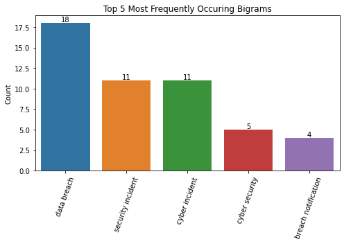

```python
import seaborn as sns

bigrams_organized_by_frequency_10 = bigram_frequency.most_common(5)

# Print the elements organized by frequency
# print('Top 10 trigrams')
bi = []
freq = []

for element, frequency in bigrams_organized_by_frequency_10:
    bigram = ' '.join(element)
    print(f'Bigram: {bigram} - Frequency: {frequency}')
    bi.append(bigram)
    freq.append(frequency)


df_bi = pd.DataFrame({'Bigram': bi, 'Count': freq})

plt.figure(figsize=(7, 5))
ax = sns.barplot(x=df_bi['Bigram'].values, y=df_bi['Count'].values)

# Display the count on each bar
for p in ax.patches:
    ax.annotate(format(p.get_height(), '.0f'), (p.get_x() + p.get_width() / 2., p.get_height()), ha = 'center', va = 'center', xytext = (0, 5), textcoords = 'offset points')

plt.ylabel('Count')
plt.title('Top 5 Most Frequently Occuring Bigrams')

plt.xticks(rotation=70)
plt.tight_layout()
plt.show()
```

### Trigrams for titles

```python
trigrams = []
for row in df['trigrams_Title_nltk']:
    trigrams.extend(row)

print(f'Count of trigrams: {len(trigrams)}')
print("\n")

# Count the frequency of each trigram
trigram_frequency = Counter(trigrams)

# Organize elements by frequency using most_common()
trigrams_organized_by_frequency = trigram_frequency.most_common()

# Print the elements organized by frequency
for element, frequency in trigrams_organized_by_frequency:
    print(element, frequency)
```

```
Count of trigrams: 230


('data', 'breach', 'notification') 4
('cyber', 'security', 'incident') 4
('data', 'security', 'incident') 2
('unauthorised', 'activity', 'system') 1
('canva', 'security', 'incident') 1
('security', 'incident', 'may') 1
('incident', 'may', 'faq') 1
('cyber', 'attack', 'acu') 1
('attack', 'acu', 'system') 1
('nab', 'apologises', 'customer') 1
('apologises', 'customer', 'data') 1
('customer', 'data', 'breach') 1
('important', 'update', 'personal') 1
('update', 'personal', 'information') 1
('statement', 'ceo', 'information') 1
('ceo', 'information', 'breach') 1
('perth', 'mint', 'experience') 1
('mint', 'experience', 'data') 1
('experience', 'data', 'breach') 1
('henning', 'harders', 'client') 1
('harders', 'client', 'information') 1
('toll', 'system', 'update') 1
('service', 'nsw', 'cyber') 1
('nsw', 'cyber', 'incident') 1
('lion', 'cyber', 'incident') 1
('cyber', 'incident', 'update') 1
('clarification', 'report', 'data') 1
('report', 'data', 'breach') 1
('regis', 'healthcare', 'response') 1
('healthcare', 'response', 'cyber') 1
('response', 'cyber', 'incident') 1
('asx', 'announcement', 'bwx') 1
('announcement', 'bwx', 'limited') 1
('bwx', 'limited', 'flora') 1
('limited', 'flora', 'fauna') 1
('flora', 'fauna', 'data') 1
('fauna', 'data', 'breach') 1
```

[output cut: 171 more lines]

```
('access', 'motocycle', 'accessory') 1
('motocycle', 'accessory', 'supermarket') 1
('accessory', 'supermarket', 'pty') 1
('supermarket', 'pty', 'ltd') 1
('myheritage', 'statement', 'cybersecurity') 1
('statement', 'cybersecurity', 'incident') 1
('unauthorised', 'activity', 'arrest') 1
('activity', 'arrest', 'suspect') 1
('arrest', 'suspect', 'faq') 1
('suspect', 'faq', 'affected') 1
('faq', 'affected', 'individual') 1
('privacy', 'data', 'breach') 1
('statement', 'cyber', 'incident') 1
('appen', 'advises', 'security') 1
('advises', 'security', 'incident') 1
```

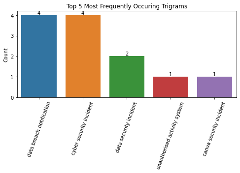

```python
trigrams_organized_by_frequency_10 = trigram_frequency.most_common(5)

# Print the elements organized by frequency
# print('Top 10 trigrams')
tri = []
freq = []

for element, frequency in trigrams_organized_by_frequency_10:
    trigram = ' '.join(element)
#     print(f'Trigram: {trigram} - Frequency: {frequency}')
    tri.append(trigram)
    freq.append(frequency)

df_tri = pd.DataFrame({'Trigram': tri, 'Count': freq})

plt.figure(figsize=(7, 5))
ax = sns.barplot(x=df_tri['Trigram'].values, y=df_tri['Count'].values)

# Display the count on each bar
for p in ax.patches:
    ax.annotate(format(p.get_height(), '.0f'), (p.get_x() + p.get_width() / 2., p.get_height()), ha = 'center', va = 'center', xytext = (0, 5), textcoords = 'offset points')

plt.ylabel('Count')
plt.title('Top 5 Most Frequently Occuring Trigrams')

plt.xticks(rotation=70)
plt.tight_layout()
plt.show()
```

### Author

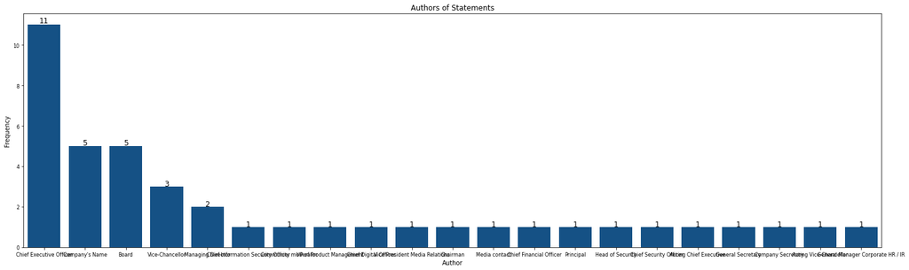

```python
# Calculate value counts
value_counts = df['Author'].value_counts(dropna=False)

import warnings
# Ignore the specific warning
warnings.filterwarnings("ignore", category=RuntimeWarning, message="Glyph 150 missing from current font.")

# Create bar plot
plt.figure(figsize=(25, 7))
p = sns.barplot(x=value_counts.index, y=value_counts.values, color='#035397')
show_values(p)
plt.xlabel('Author')
plt.ylabel('Frequency')
plt.title('Authors of Statements')
plt.xticks(fontsize=8)
plt.yticks(fontsize=8)
plt.show()
```

```python
df['Author'].value_counts(dropna=False)
```

```
NaN                                   58
Chief Executive Officer               11
Company's Name                         5
Board                                  5
Vice-Chancellor                        3
Managing Director                      2
Chief Information Security Officer     1
Community moderator                    1
VP of Product Management               1
Chief Digital Officer                  1
Vice President Media Relations         1
Chairman                               1
Media contact                          1
Chief Financial Officer                1
Principal                              1
Head of Security                       1
Chief Security Officer                 1
Acting Chief Executive                 1
General Secretary                      1
Company Secretary                      1
Acting Vice-Chancellor                 1
General Manager Corporate HR / IR      1
Name: Author, dtype: int64
```

```python
# df.to_excel('output.xlsx', index=False)
```

```python
# df.drop(['CleanStatement2'], axis=1, inplace=True)
```

## Merging two datasets

### 1. Read the other dataframes containing features generating from Text Analysis of the Statements

```python
df_features = pd.read_csv('features.csv')
df_features.info()
```

```
<class 'pandas.core.frame.DataFrame'>
RangeIndex: 100 entries, 0 to 99
Data columns (total 29 columns):
 #   Column                 Non-Null Count  Dtype
---  ------                 --------------  -----
 0   Name                   100 non-null    object
 1   NotificationDate       100 non-null    object
 2   Year                   100 non-null    int64
 3   Statement              100 non-null    object
 4   SentimentScores        100 non-null    object
 5   VaderSentiment         100 non-null    object
 6   CleanSentimentScores   100 non-null    object
 7   PositiveCount          100 non-null    int64
 8   NegativeCount          100 non-null    int64
 9   PosNegRatio            100 non-null    float64
```

[output cut: 21 more lines]

### 2. Fix some typo errors

```python
df_features[df_features['Name']=='Canva']
```

|  | Name | NotificationDate | Year | Statement | SentimentScores | VaderSentiment | CleanSentimentScores | PositiveCount | NegativeCount | PosNegRatio | ... | CyberKeywordCount | AuthorityKeywordCount | FAQKeywordCount | AvgWordLength | AvgSentenceLength | UniqueWordCount | StopWordCount | CharCount | PunctuationCount | EmailTagCount |
| --- | --- | --- | --- | --- | --- | --- | --- | --- | --- | --- | --- | --- | --- | --- | --- | --- | --- | --- | --- | --- | --- |
| 19 | Canva | 24/05/2019 | 2019 | June 1, 10:13 AEST Following an investigation... | (23, 24, 0.9874929371087448, 0.9956864565610886) | Neutral | ['23', '24', '0.9874929371087448', '0.99568645... | 23 | 24 | 0.958333 | ... | 4 | 0 | 0 | 4.885478 | 19.25 | 440 | 376 | 5118 | 111 | 0 |

1 rows × 29 columns

```python
# Fix Canva's notification date
df_features.loc[19, 'NotificationDate'] = '01/06/2019'
```

```python
df_features[(df_features['Name']=='Optus') & (df_features['NotificationDate']=='20/09/2022')]
```

|  | Name | NotificationDate | Year | Statement | SentimentScores | VaderSentiment | CleanSentimentScores | PositiveCount | NegativeCount | PosNegRatio | ... | CyberKeywordCount | AuthorityKeywordCount | FAQKeywordCount | AvgWordLength | AvgSentenceLength | UniqueWordCount | StopWordCount | CharCount | PunctuationCount | EmailTagCount |
| --- | --- | --- | --- | --- | --- | --- | --- | --- | --- | --- | --- | --- | --- | --- | --- | --- | --- | --- | --- | --- | --- |
| 65 | Optus | 20/09/2022 | 2022 | Following a cyberattack, Optus is investigatin... | (11, 8, 0.9959407177838412, 0.9943792149424553) | Neutral | ['11', '8', '0.9959407177838412', '0.994379214... | 11 | 8 | 1.375 | ... | 3 | 4 | 0 | 5.38806 | 14.75 | 247 | 163 | 2652 | 67 | 1 |

1 rows × 29 columns

```python
# Fix Optus's notification date
df_features.loc[65, 'NotificationDate'] = '22/09/2022'
```

```python
df_features[(df_features['Name']=='Optus')]
```

|  | Name | NotificationDate | Year | Statement | SentimentScores | VaderSentiment | CleanSentimentScores | PositiveCount | NegativeCount | PosNegRatio | ... | CyberKeywordCount | AuthorityKeywordCount | FAQKeywordCount | AvgWordLength | AvgSentenceLength | UniqueWordCount | StopWordCount | CharCount | PunctuationCount | EmailTagCount |
| --- | --- | --- | --- | --- | --- | --- | --- | --- | --- | --- | --- | --- | --- | --- | --- | --- | --- | --- | --- | --- | --- |
| 24 | Optus | 17/10/2019 | 2019 | Hi We're getting in touch because we've mista... | (6, 7, 0.991364320119222, 0.9905413900102887) | Positive | ['6', '7', '0.991364320119222', '0.99054139001... | 6 | 7 | 0.857143 | ... | 0 | 0 | 0 | 5.00000 | 19.923077 | 175 | 119 | 1581 | 47 | 0 |
| 65 | Optus | 22/09/2022 | 2022 | Following a cyberattack, Optus is investigatin... | (11, 8, 0.9959407177838412, 0.9943792149424553) | Neutral | ['11', '8', '0.9959407177838412', '0.994379214... | 11 | 8 | 1.375000 | ... | 3 | 4 | 0 | 5.38806 | 14.750000 | 247 | 163 | 2652 | 67 | 1 |

2 rows × 29 columns

```python
df_features[(df_features['Name']=='PageUp People')]
```

|  | Name | NotificationDate | Year | Statement | SentimentScores | VaderSentiment | CleanSentimentScores | PositiveCount | NegativeCount | PosNegRatio | ... | CyberKeywordCount | AuthorityKeywordCount | FAQKeywordCount | AvgWordLength | AvgSentenceLength | UniqueWordCount | StopWordCount | CharCount | PunctuationCount | EmailTagCount |
| --- | --- | --- | --- | --- | --- | --- | --- | --- | --- | --- | --- | --- | --- | --- | --- | --- | --- | --- | --- | --- | --- |
| 3 | PageUp People | 06/05/2018 | 2018 | Information update 5 June 2018 As part of our... | (7, 3, 0.9801284670829773, 0.9722663958867391) | Positive | ['7', '3', '0.9801284670829773', '0.9722663958... | 7 | 3 | 2.333333 | ... | 1 | 0 | 2 | 5.240566 | 21.2 | 150 | 91 | 1349 | 21 | 0 |

1 rows × 29 columns

```python
# Fix PageUpPeople's notification date
df_features.loc[3, 'NotificationDate'] = '05/06/2018'
```

```python
df_features[(df_features['Name']=='Big Interest Group (BigFooty).com')]
```

|  | Name | NotificationDate | Year | Statement | SentimentScores | VaderSentiment | CleanSentimentScores | PositiveCount | NegativeCount | PosNegRatio | ... | CyberKeywordCount | AuthorityKeywordCount | FAQKeywordCount | AvgWordLength | AvgSentenceLength | UniqueWordCount | StopWordCount | CharCount | PunctuationCount | EmailTagCount |
| --- | --- | --- | --- | --- | --- | --- | --- | --- | --- | --- | --- | --- | --- | --- | --- | --- | --- | --- | --- | --- | --- |
| 34 | Big Interest Group (BigFooty).com | 29/05/2020 | 2020 | What happened? Recently we learned of a secur... | (12, 21, 0.9906089951594671, 0.9957154904093061) | Positive | ['12', '21', '0.9906089951594671', '0.99571549... | 12 | 21 | 0.571429 | ... | 2 | 0 | 0 | 5.47943 | 15.0 | 352 | 275 | 4301 | 166 | 1 |

1 rows × 29 columns

```python
# Fix Big Interest Group's name
df_features.loc[34, 'Name'] = 'Big Interest Group (BigFooty)'
```

### 3. Checking if two dataframes' names and notification dates are the same

```python
df1 = df[['Name', 'NotificationDate']].sort_values(by='Name').reset_index(drop=True)
```

```python
df1.info()
```

```
<class 'pandas.core.frame.DataFrame'>
RangeIndex: 100 entries, 0 to 99
Data columns (total 2 columns):
 #   Column            Non-Null Count  Dtype
---  ------            --------------  -----
 0   Name              100 non-null    object
 1   NotificationDate  100 non-null    object
dtypes: object(2)
memory usage: 1.7+ KB
```

```python
df1.head()
```

|  | Name | NotificationDate |
| --- | --- | --- |
| 0 | ACT Education Directorate | 14/08/2020 |
| 1 | Ambulance Tasmania | 05/02/2021 |
| 2 | Ambulance Victoria | 19/05/2023 |
| 3 | Amnesty International Australia | 28/04/2023 |
| 4 | Anglicare Sydney | 02/09/2020 |

```python
df2 = df_features[['Name', 'NotificationDate']].sort_values(by='Name').reset_index(drop=True)
```

```python
df2.info()
```

```
<class 'pandas.core.frame.DataFrame'>
RangeIndex: 100 entries, 0 to 99
Data columns (total 2 columns):
 #   Column            Non-Null Count  Dtype
---  ------            --------------  -----
 0   Name              100 non-null    object
 1   NotificationDate  100 non-null    object
dtypes: object(2)
memory usage: 1.7+ KB
```

```python
df2.head()
```

|  | Name | NotificationDate |
| --- | --- | --- |
| 0 | ACT Education Directorate | 14/08/2020 |
| 1 | Ambulance Tasmania | 05/02/2021 |
| 2 | Ambulance Victoria | 19/05/2023 |
| 3 | Amnesty International Australia | 28/04/2023 |
| 4 | Anglicare Sydney | 02/09/2020 |

```python
# Check if values in two columns are the same and return rows that are different
mask = (df1['Name'] != df2['Name']) | (df1['NotificationDate'] != df2['NotificationDate'])
different_rows = df1[mask]
```

```python
different_rows
```

|  | Name | NotificationDate |
| --- | --- | --- |
| 59 | Optus | 17/10/2019 |
| 60 | Optus | 22/09/2022 |
| 82 | TPG Telecom | 14/12/2022 |
| 83 | TPG Telecom | 24/05/2021 |

### 4. Join two dataframes based on Name & Notification Date

```python
merged_df = pd.merge(df, df_features, on=['Name', 'NotificationDate'], how='left')
```

```python
merged_df.info()
```

```
<class 'pandas.core.frame.DataFrame'>
Int64Index: 100 entries, 0 to 99
Data columns (total 69 columns):
 #   Column                     Non-Null Count  Dtype
---  ------                     --------------  -----
 0   Name                       100 non-null    object
 1   CountryOfNotification      100 non-null    object
 2   DataBreachSource           100 non-null    object
 3   IncidentDescription        16 non-null     object
 4   NumberOfAusPeopleAffected  41 non-null     object
 5   IncidentDay                83 non-null     float64
 6   IncidentMonth              98 non-null     float64
 7   IncidentYear               100 non-null    int64
 8   NotificationDate           100 non-null    object
 9   NotificationURL            100 non-null    object
```

[output cut: 61 more lines]

#### Checking if the merge is correct

```python
merged_df[merged_df['Name']=='Optus']
```

|  | Name | CountryOfNotification | DataBreachSource | IncidentDescription | NumberOfAusPeopleAffected | IncidentDay | IncidentMonth | IncidentYear | NotificationDate | NotificationURL | ... | CyberKeywordCount | AuthorityKeywordCount | FAQKeywordCount | AvgWordLength | AvgSentenceLength | UniqueWordCount | StopWordCount | CharCount | PunctuationCount | EmailTagCount |
| --- | --- | --- | --- | --- | --- | --- | --- | --- | --- | --- | --- | --- | --- | --- | --- | --- | --- | --- | --- | --- | --- |
| 5 | Optus | Australia | System fault | NaN | 50000 | 17.0 | 10.0 | 2019 | 17/10/2019 | https://www.facebook.com/photo.php?fbid=102213... | ... | 0 | 0 | 0 | 5.00000 | 19.923077 | 175 | 119 | 1581 | 47 | 0 |
| 37 | Optus | Australia | Malicious or criminal attack | NaN | 10200 | 20.0 | 9.0 | 2022 | 22/09/2022 | https://www.optus.com.au/about/media-centre/me... | ... | 3 | 4 | 0 | 5.38806 | 14.750000 | 247 | 163 | 2652 | 67 | 1 |

2 rows × 69 columns

```python
df_features[df_features['Name']=='Optus']
```

|  | Name | NotificationDate | Year | Statement | SentimentScores | VaderSentiment | CleanSentimentScores | PositiveCount | NegativeCount | PosNegRatio | ... | CyberKeywordCount | AuthorityKeywordCount | FAQKeywordCount | AvgWordLength | AvgSentenceLength | UniqueWordCount | StopWordCount | CharCount | PunctuationCount | EmailTagCount |
| --- | --- | --- | --- | --- | --- | --- | --- | --- | --- | --- | --- | --- | --- | --- | --- | --- | --- | --- | --- | --- | --- |
| 24 | Optus | 17/10/2019 | 2019 | Hi We're getting in touch because we've mista... | (6, 7, 0.991364320119222, 0.9905413900102887) | Positive | ['6', '7', '0.991364320119222', '0.99054139001... | 6 | 7 | 0.857143 | ... | 0 | 0 | 0 | 5.00000 | 19.923077 | 175 | 119 | 1581 | 47 | 0 |
| 65 | Optus | 22/09/2022 | 2022 | Following a cyberattack, Optus is investigatin... | (11, 8, 0.9959407177838412, 0.9943792149424553) | Neutral | ['11', '8', '0.9959407177838412', '0.994379214... | 11 | 8 | 1.375000 | ... | 3 | 4 | 0 | 5.38806 | 14.750000 | 247 | 163 | 2652 | 67 | 1 |

2 rows × 29 columns

```python
merged_df[merged_df['Name']=='TPG Telecom']
```

|  | Name | CountryOfNotification | DataBreachSource | IncidentDescription | NumberOfAusPeopleAffected | IncidentDay | IncidentMonth | IncidentYear | NotificationDate | NotificationURL | ... | CyberKeywordCount | AuthorityKeywordCount | FAQKeywordCount | AvgWordLength | AvgSentenceLength | UniqueWordCount | StopWordCount | CharCount | PunctuationCount | EmailTagCount |
| --- | --- | --- | --- | --- | --- | --- | --- | --- | --- | --- | --- | --- | --- | --- | --- | --- | --- | --- | --- | --- | --- |
| 24 | TPG Telecom | Australia | Malicious or criminal attack | NaN | 2 | 24.0 | 5.0 | 2021 | 24/05/2021 | https://www.tpgtelecom.com.au/sites/default/fi... | ... | 2 | 0 | 0 | 5.602459 | 14.529412 | 138 | 115 | 1648 | 27 | 1 |
| 51 | TPG Telecom | Australia | Malicious or criminal attack | NaN | 15000 | 13.0 | 12.0 | 2022 | 14/12/2022 | https://wcsecure.weblink.com.au/pdf/TPG/026122... | ... | 2 | 0 | 0 | 5.726872 | 13.705882 | 150 | 86 | 1560 | 31 | 2 |

2 rows × 69 columns

```python
df_features[df_features['Name']=='TPG Telecom']
```

|  | Name | NotificationDate | Year | Statement | SentimentScores | VaderSentiment | CleanSentimentScores | PositiveCount | NegativeCount | PosNegRatio | ... | CyberKeywordCount | AuthorityKeywordCount | FAQKeywordCount | AvgWordLength | AvgSentenceLength | UniqueWordCount | StopWordCount | CharCount | PunctuationCount | EmailTagCount |
| --- | --- | --- | --- | --- | --- | --- | --- | --- | --- | --- | --- | --- | --- | --- | --- | --- | --- | --- | --- | --- | --- |
| 52 | TPG Telecom | 24/05/2021 | 2021 | TPG Telecom Limited notes that its legacy clou... | (8, 6, 0.9949794113636017, 0.9853125115235647) | Positive | ['8', '6', '0.9949794113636017', '0.9853125115... | 8 | 6 | 1.333333 | ... | 2 | 0 | 0 | 5.602459 | 14.529412 | 138 | 115 | 1648 | 27 | 1 |
| 81 | TPG Telecom | 14/12/2022 | 2022 | On 13 December 2022, TPG Telecom’s external cy... | (7, 4, 0.9903367161750793, 0.9949693083763123) | Neutral | ['7', '4', '0.9903367161750793', '0.9949693083... | 7 | 4 | 1.750000 | ... | 2 | 0 | 0 | 5.726872 | 13.705882 | 150 | 86 | 1560 | 31 | 2 |

2 rows × 29 columns

```python
df[response_col]
```

|  | FullTransparency | Guarded | Opacity | CustomerInterest | BalancedInterest | CompanyInterest |
| --- | --- | --- | --- | --- | --- | --- |
| 0 | 0 | 0 | 0 | 0 | 1 | 0 |
| 1 | 1 | 0 | 0 | 1 | 0 | 0 |
| 2 | 0 | 0 | 0 | 0 | 1 | 0 |
| 3 | 1 | 0 | 0 | 0 | 1 | 0 |
| 4 | 1 | 0 | 0 | 1 | 0 | 0 |
| ... | ... | ... | ... | ... | ... | ... |
| 95 | 0 | 0 | 0 | 0 | 0 | 1 |
| 96 | 1 | 0 | 0 | 0 | 1 | 0 |
| 97 | 0 | 0 | 0 | 1 | 0 | 0 |
| 98 | 0 | 0 | 0 | 0 | 0 | 0 |
| 99 | 0 | 0 | 0 | 0 | 0 | 1 |

100 rows × 6 columns

```python
# Use np.where to check conditions and assign values
df['LevelOfDetail'] = np.where(df['FullTransparency'] == 1, 1,
               np.where(df['Guarded'] == 1, 2,
                 np.where(df['Opacity'] == 1, 3, 0)))
```

```python
df['LevelOfDetail'].value_counts()
```

```
0    75
1    23
3     2
Name: LevelOfDetail, dtype: int64
```

```python
df[df['Opacity'] == 1]
```

|  | Name | CountryOfNotification | DataBreachSource | IncidentDescription | NumberOfAusPeopleAffected | IncidentDay | IncidentMonth | IncidentYear | NotificationDate | NotificationURL | ... | CustomerInterest | BalancedInterest | CompanyInterest | LevelOfDetail | BenefitParty | ManualLabel | CombinedLabel | Title_nltk | bigrams_Title_nltk | trigrams_Title_nltk |
| --- | --- | --- | --- | --- | --- | --- | --- | --- | --- | --- | --- | --- | --- | --- | --- | --- | --- | --- | --- | --- | --- |
| 20 | Nitro Software | Australia | Malicious or criminal attack | NaN | NaN | 30.0 | 9.0 | 2020 | 21/10/2020 | https://ir.gonitro.com/Investor-Centre/?page=a... | ... | 0 | 0 | 1 | 3 | 3 | NaN | 3.0 | nitro advises low impact security incident | [(nitro, advises), (advises, low), (low, impac... | [(nitro, advises, low), (advises, low, impact)... |
| 83 | Austal | Australia | Malicious or criminal attack | NaN | NaN | 1.0 | 11.0 | 2018 | 01/11/2018 | https://announcements.asx.com.au/asxpdf/201811... | ... | 0 | 0 | 1 | 3 | 3 | NaN | 3.0 | statement austal australia data breach | [(statement, austal), (austal, australia), (au... | [(statement, austal, australia), (austal, aust... |

2 rows × 42 columns

```python
# Use np.where to check conditions and assign values
df['BenefitParty'] = np.where(df['CustomerInterest'] == 1, 1,
               np.where(df['BalancedInterest'] == 1, 2,
                 np.where(df['CompanyInterest'] == 1, 3, 0)))
```

```python
df['BenefitParty'].value_counts()
```

```
2    35
0    32
3    17
1    16
Name: BenefitParty, dtype: int64
```

```python
df[['Name', 'LevelOfDetail','BenefitParty']]
```

|  | Name | LevelOfDetail | BenefitParty |
| --- | --- | --- | --- |
| 0 | PageUp People | 0 | 2 |
| 1 | Canva | 1 | 1 |
| 2 | Australian National University | 0 | 2 |
| 3 | Australian Catholic University | 1 | 2 |
| 4 | NAB | 1 | 1 |
| ... | ... | ... | ... |
| 95 | ProctorU | 0 | 3 |
| 96 | City of Port Phillip council | 1 | 2 |
| 97 | RCR Tomlinson | 0 | 1 |
| 98 | Aristocrat | 0 | 0 |
| 99 | Appen | 0 | 3 |

100 rows × 3 columns

### Final dataset for modelling

```python
merged_df.iloc[:,:14][:3]
```

|  | Name | CountryOfNotification | DataBreachSource | IncidentDescription | NumberOfAusPeopleAffected | IncidentDay | IncidentMonth | IncidentYear | NotificationDate | NotificationURL | Title | Channel | MediaURL | CompanyDescription |
| --- | --- | --- | --- | --- | --- | --- | --- | --- | --- | --- | --- | --- | --- | --- |
| 0 | PageUp People | Australia | Malicious or criminal attack | NaN | NaN | 23.0 | 5.0 | 2018 | 05/06/2018 | https://web.archive.org/web/20190813054217/htt... | Unauthorised Activity on IT System | Website | https://www.itnews.com.au/news/pageup-people-h... | Enterprise Talent Management Software |
| 1 | Canva | Australia | Malicious or criminal attack | NaN | 139000000 | 24.0 | 5.0 | 2019 | 01/06/2019 | https://www.canva.com/help/incident-may24/ | Canva Security Incident  May 24 FAQs | Website | NaN | Design |
| 2 | Australian National University | Australia | Malicious or criminal attack | NaN | NaN | NaN | 11.0 | 2018 | 04/06/2019 | https://www.anu.edu.au/news/all-news/message-f... | Message from the Vice-Chancellor | Website | https://www.anu.edu.au/news/all-news/vcs-messa... | Educational Institution |

```python
merged_df.iloc[:,14:28][:3]
```

|  | Sector | Author | DataType | DetailedExplanation | Whitewashing | Apology | Compensation | ResponsiveAction | ValueCommitment | CustomerFocus | OpenDisclosure | CustomerAdvice | ExtraMediaURL1 | ExtraMediaURL2 |
| --- | --- | --- | --- | --- | --- | --- | --- | --- | --- | --- | --- | --- | --- | --- |
| 0 | Information media and telecommunications | Chief Executive Officer | name, street address, email address, telephone... | 2.0 | NaN | 5.0 | NaN | 3.0 | 1.0 | NaN | NaN | 4.0 | NaN | NaN |
| 1 | Information media and telecommunications | Head of Security | username, name, email address, country, city, ... | 1.0 | NaN | 7.0 | 6.0 | 2.0 | 4.0 | 8.0 | 3.0 | 5.0 | NaN | NaN |
| 2 | Education and training | Vice-Chancellor | name, address, date of birth, phone number, pe... | 2.0 | 7.0 | 1.0 | NaN | 3.0 | 5.0 | NaN | 4.0 | 6.0 | NaN | NaN |

```python
merged_df.iloc[:,28:42][:3]
```

|  | Notes | FullTransparency | Guarded | Opacity | CustomerInterest | BalancedInterest | CompanyInterest | LevelOfDetail | BenefitParty | ManualLabel | CombinedLabel | Title_nltk | bigrams_Title_nltk | trigrams_Title_nltk |
| --- | --- | --- | --- | --- | --- | --- | --- | --- | --- | --- | --- | --- | --- | --- |
| 0 | Different types of data compromised by employe... | 0 | 0 | 0 | 0 | 1 | 0 | 0 | 2 | 2.0 | 2.0 | unauthorised activity system | [(unauthorised, activity), (activity, system)] | [(unauthorised, activity, system)] |
| 1 | NaN | 1 | 0 | 0 | 1 | 0 | 0 | 1 | 1 | NaN | 1.0 | canva security incident may faq | [(canva, security), (security, incident), (inc... | [(canva, security, incident), (security, incid... |
| 2 | NaN | 0 | 0 | 0 | 0 | 1 | 0 | 0 | 2 | 2.0 | 2.0 | message vicechancellor | [(message, vicechancellor)] | [] |

```python
merged_df.iloc[:,42:61][:3]
```

|  | Year | Statement | SentimentScores | VaderSentiment | CleanSentimentScores | PositiveCount | NegativeCount | PosNegRatio | PosTotalRatio | AvgPositiveConf | AvgNegativeConf | WordCount | SentenceCount | ReadingEase | Flesch-KincaidGrade | ReadabilityConsensus | HyperlinksCount | CyberKeywordCount | AuthorityKeywordCount |
| --- | --- | --- | --- | --- | --- | --- | --- | --- | --- | --- | --- | --- | --- | --- | --- | --- | --- | --- | --- |
| 0 | 2018 | Information update 5 June 2018 As part of our... | (7, 3, 0.9801284670829773, 0.9722663958867391) | Positive | ['7', '3', '0.9801284670829773', '0.9722663958... | 7 | 3 | 2.333333 | 0.700000 | 0.980128 | 0.972266 | 212 | 9 | 39.06 | 13.7 | 15th and 16th grade | 0 | 1 | 0 |
| 1 | 2019 | June 1, 10:13 AEST Following an investigation... | (23, 24, 0.9874929371087448, 0.9956864565610886) | Neutral | ['23', '24', '0.9874929371087448', '0.99568645... | 23 | 24 | 0.958333 | 0.489362 | 0.987493 | 0.995686 | 847 | 47 | 61.67 | 9.1 | 10th and 11th grade | 0 | 4 | 0 |
| 2 | 2019 | Dear all, It is with profound regret I infor... | (21, 7, 0.9896519751775832, 0.9955804944038391) | Positive | ['21', '7', '0.9896519751775832', '0.995580494... | 21 | 7 | 3.000000 | 0.750000 | 0.989652 | 0.995580 | 503 | 29 | 45.46 | 11.2 | 11th and 12th grade | 0 | 5 | 0 |

```python
merged_df.info()
```

```
<class 'pandas.core.frame.DataFrame'>
Int64Index: 100 entries, 0 to 99
Data columns (total 69 columns):
 #   Column                     Non-Null Count  Dtype
---  ------                     --------------  -----
 0   Name                       100 non-null    object
 1   CountryOfNotification      100 non-null    object
 2   DataBreachSource           100 non-null    object
 3   IncidentDescription        16 non-null     object
 4   NumberOfAusPeopleAffected  41 non-null     object
 5   IncidentDay                83 non-null     float64
 6   IncidentMonth              98 non-null     float64
 7   IncidentYear               100 non-null    int64
 8   NotificationDate           100 non-null    object
 9   NotificationURL            100 non-null    object
```

[output cut: 61 more lines]

#### Create column for Timelag

```python
merged_df['NotificationDate'].head()
```

```
0    05/06/2018
1    01/06/2019
2    04/06/2019
3    17/06/2019
4    26/07/2019
Name: NotificationDate, dtype: object
```

```python
merged_df['IncidentDate'] = incident_date
```

```python
merged_df['IncidentDate'].head()
```

```
0    23/05/2018
1    24/05/2019
2           NaN
3    22/05/2019
4    24/07/2019
Name: IncidentDate, dtype: object
```

```python
merged_df[merged_df['IncidentDate'].isna()].head()
```

|  | Name | CountryOfNotification | DataBreachSource | IncidentDescription | NumberOfAusPeopleAffected | IncidentDay | IncidentMonth | IncidentYear | NotificationDate | NotificationURL | ... | AuthorityKeywordCount | FAQKeywordCount | AvgWordLength | AvgSentenceLength | UniqueWordCount | StopWordCount | CharCount | PunctuationCount | EmailTagCount | IncidentDate |
| --- | --- | --- | --- | --- | --- | --- | --- | --- | --- | --- | --- | --- | --- | --- | --- | --- | --- | --- | --- | --- | --- |
| 2 | Australian National University | Australia | Malicious or criminal attack | NaN | NaN | NaN | 11.0 | 2018 | 04/06/2019 | https://www.anu.edu.au/news/all-news/message-f... | ... | 0 | 1 | 5.143141 | 16.833333 | 281 | 229 | 3206 | 61 | 1 | NaN |
| 10 | Service NSW | Australia | Malicious or criminal attack | NaN | 104000 | NaN | 3.0 | 2020 | 28/05/2020 | https://www.service.nsw.gov.au/cyber-incident#... | ... | 0 | 0 | 5.047904 | 27.833333 | 102 | 77 | 1024 | 9 | 0 | NaN |
| 17 | Scouts Victoria | Australia | Malicious or criminal attack | NaN | 900 | NaN | 7.0 | 2020 | 24/09/2020 | https://scoutsvictoria.com.au/about-us/news/no... | ... | 2 | 0 | 5.841935 | 23.923077 | 206 | 98 | 2177 | 42 | 0 | NaN |
| 26 | SA Ambulance Service | Australia | Human error | NaN | 28000 | NaN | 11.0 | 2021 | 10/11/2021 | https://www.sahealth.sa.gov.au/wps/wcm/connect... | ... | 6 | 0 | 5.145161 | 15.344828 | 435 | 355 | 5489 | 133 | 1 | NaN |
| 30 | Transport for NSW | Australia | Malicious or criminal attack | NaN | NaN | NaN | 4.0 | 2022 | 04/05/2022 | https://www.transport.nsw.gov.au/news-and-even... | ... | 0 | 0 | 5.632143 | 14.150000 | 181 | 106 | 1919 | 36 | 1 | NaN |

5 rows × 70 columns

```python
from datetime import datetime
date_format = "%d/%m/%Y"
merged_df["NotificationDate"] = merged_df["NotificationDate"].apply(lambda x: datetime.strptime(x, date_format))
```

```python
merged_df["IncidentDate"] = merged_df["IncidentDate"].apply(lambda x: datetime.strptime(x, date_format)
                                                                   if isinstance(x, str) else np.nan
                                                           )
```

```python
merged_df['NotificationDate'].head()
```

```
0   2018-06-05
1   2019-06-01
2   2019-06-04
3   2019-06-17
4   2019-07-26
Name: NotificationDate, dtype: datetime64[ns]
```

```python
merged_df['IncidentDate'].head()
```

```
0   2018-05-23
1   2019-05-24
2          NaT
3   2019-05-22
4   2019-07-24
Name: IncidentDate, dtype: datetime64[ns]
```

```python
# Create a feature for Timelag in days
merged_df['Timelag'] = (merged_df["NotificationDate"] - merged_df["IncidentDate"])
merged_df['Timelag(Days)'] = merged_df['Timelag'].apply(lambda x: x.days)
```

```python
merged_df['IncidentDate'].value_counts(dropna=False)[:3]
```

```
NaT           17
2022-11-03     2
2022-12-03     1
Name: IncidentDate, dtype: int64
```

```python
merged_df['Timelag'].value_counts(dropna=False)[:3]
```

```
0 days    21
NaT       17
1 days     8
Name: Timelag, dtype: int64
```

```python
merged_df[merged_df["IncidentDate"].isna()][:3]
```

|  | Name | CountryOfNotification | DataBreachSource | IncidentDescription | NumberOfAusPeopleAffected | IncidentDay | IncidentMonth | IncidentYear | NotificationDate | NotificationURL | ... | AvgWordLength | AvgSentenceLength | UniqueWordCount | StopWordCount | CharCount | PunctuationCount | EmailTagCount | IncidentDate | Timelag | Timelag(Days) |
| --- | --- | --- | --- | --- | --- | --- | --- | --- | --- | --- | --- | --- | --- | --- | --- | --- | --- | --- | --- | --- | --- |
| 2 | Australian National University | Australia | Malicious or criminal attack | NaN | NaN | NaN | 11.0 | 2018 | 2019-06-04 | https://www.anu.edu.au/news/all-news/message-f... | ... | 5.143141 | 16.833333 | 281 | 229 | 3206 | 61 | 1 | NaT | NaT | NaN |
| 10 | Service NSW | Australia | Malicious or criminal attack | NaN | 104000 | NaN | 3.0 | 2020 | 2020-05-28 | https://www.service.nsw.gov.au/cyber-incident#... | ... | 5.047904 | 27.833333 | 102 | 77 | 1024 | 9 | 0 | NaT | NaT | NaN |
| 17 | Scouts Victoria | Australia | Malicious or criminal attack | NaN | 900 | NaN | 7.0 | 2020 | 2020-09-24 | https://scoutsvictoria.com.au/about-us/news/no... | ... | 5.841935 | 23.923077 | 206 | 98 | 2177 | 42 | 0 | NaT | NaT | NaN |

3 rows × 72 columns

```python
merged_df['Timelag(Days)'].value_counts(dropna=False).sort_index()
```

```
0.0      21
1.0       8
2.0       4
3.0       6
4.0       3
6.0       2
8.0       4
9.0       1
10.0      1
11.0      1
12.0      1
13.0      1
14.0      1
15.0      3
18.0      1
19.0      2
21.0      1
22.0      1
26.0      1
27.0      2
28.0      1
33.0      1
35.0      1
41.0      1
48.0      2
54.0      1
64.0      2
65.0      1
74.0      1
83.0      1
87.0      1
131.0     1
146.0     1
152.0     1
218.0     1
221.0     1
NaN      17
Name: Timelag(Days), dtype: int64
```

```python
merged_df.tail()
```

|  | Name | CountryOfNotification | DataBreachSource | IncidentDescription | NumberOfAusPeopleAffected | IncidentDay | IncidentMonth | IncidentYear | NotificationDate | NotificationURL | ... | AvgWordLength | AvgSentenceLength | UniqueWordCount | StopWordCount | CharCount | PunctuationCount | EmailTagCount | IncidentDate | Timelag | Timelag(Days) |
| --- | --- | --- | --- | --- | --- | --- | --- | --- | --- | --- | --- | --- | --- | --- | --- | --- | --- | --- | --- | --- | --- |
| 95 | ProctorU | Global | Malicious or criminal attack | NaN | NaN | 27.0 | 7.0 | 2020 | 2020-08-07 | https://web.archive.org/web/20200807192353/htt... | ... | 5.472973 | 14.800000 | 61 | 30 | 493 | 11 | 0 | 2020-07-27 | 11 days | 11.0 |
| 96 | City of Port Phillip council | Australia | Human error | Personal information was accidently disclosed ... | NaN | NaN | 3.0 | 2020 | 2020-10-28 | https://web.archive.org/web/20201124124412/htt... | ... | 5.288603 | 14.684211 | 268 | 235 | 3497 | 63 | 1 | NaT | NaT | NaN |
| 97 | RCR Tomlinson | Australia | Malicious or criminal attack | NaN | NaN | 17.0 | 5.0 | 2018 | 2018-07-04 | https://web.archive.org.au/awa/20190509041051m... | ... | 5.088899 | 25.304348 | 758 | 1035 | 14089 | 197 | 1 | 2018-05-17 | 48 days | 48.0 |
| 98 | Aristocrat | Australia | Malicious or criminal attack | hacker exploited a newly identified (zero day)... | NaN | 1.0 | 6.0 | 2023 | 2023-08-04 | https://www.aristocrat.com/statement-on-cyber-... | ... | 6.112971 | 20.166667 | 170 | 75 | 1751 | 40 | 2 | 2023-06-01 | 64 days | 64.0 |
| 99 | Appen | Australia | Malicious or criminal attack | Malicious actors hacked the systems of the thi... | NaN | NaN | 7.0 | 2020 | 2020-07-30 | https://yourir.info/resources/396cdf0a32f7cb50... | ... | 5.500978 | 18.321429 | 291 | 202 | 3416 | 86 | 2 | NaT | NaT | NaN |

5 rows × 72 columns

```python
merged_df[merged_df['Timelag(Days)'] < 0].head()
```

|  | Name | CountryOfNotification | DataBreachSource | IncidentDescription | NumberOfAusPeopleAffected | IncidentDay | IncidentMonth | IncidentYear | NotificationDate | NotificationURL | ... | AvgWordLength | AvgSentenceLength | UniqueWordCount | StopWordCount | CharCount | PunctuationCount | EmailTagCount | IncidentDate | Timelag | Timelag(Days) |
| --- | --- | --- | --- | --- | --- | --- | --- | --- | --- | --- | --- | --- | --- | --- | --- | --- | --- | --- | --- | --- | --- |

0 rows × 72 columns

```python
import math
def discretisation(x):
    if math.isnan(x):
        return 'undefinable'
    elif 0 < x <=30:
        return "less than a month"
    elif 31 < x <= 60:
        return "more than 1 month"
    elif 61 < x <= 90:
        return "more than 2 months"
    else:
        return "more than 3 months"
```

```python
merged_df['TimelagGroup'] = merged_df['Timelag(Days)'].apply(lambda x: discretisation(x))
```

```python
merged_df[merged_df['TimelagGroup'].isna()]
```

|  | Name | CountryOfNotification | DataBreachSource | IncidentDescription | NumberOfAusPeopleAffected | IncidentDay | IncidentMonth | IncidentYear | NotificationDate | NotificationURL | ... | AvgSentenceLength | UniqueWordCount | StopWordCount | CharCount | PunctuationCount | EmailTagCount | IncidentDate | Timelag | Timelag(Days) | TimelagGroup |
| --- | --- | --- | --- | --- | --- | --- | --- | --- | --- | --- | --- | --- | --- | --- | --- | --- | --- | --- | --- | --- | --- |

0 rows × 73 columns

```python
merged_df['TimelagGroup'].value_counts(dropna=False, normalize=True)
```

```
less than a month     0.45
more than 3 months    0.26
undefinable           0.17
more than 1 month     0.06
more than 2 months    0.06
Name: TimelagGroup, dtype: float64
```

```python
merged_df['TimelagGroup'].tail()
```

```
95     less than a month
96           undefinable
97     more than 1 month
98    more than 2 months
99           undefinable
Name: TimelagGroup, dtype: object
```

```python
# Task 13
# Frequency Encoding of the Age Group variable

# generate the frequency encoding for each categorical value in the target column
fr_enc = (merged_df.groupby("TimelagGroup", dropna=False).size()) / len(merged_df)

# print the encoding values
print(fr_enc)
```

```
TimelagGroup
less than a month     0.45
more than 1 month     0.06
more than 2 months    0.06
more than 3 months    0.26
undefinable           0.17
dtype: float64
```

```python
# create a new column that apply frequency encoding to Age Group
merged_df["TimelagGroupEncoded"] = merged_df["TimelagGroup"].apply(lambda x : fr_enc[x])
```

```python
merged_df["TimelagGroupEncoded"].value_counts()
```

```
0.45    45
0.26    26
0.17    17
0.06    12
Name: TimelagGroupEncoded, dtype: int64
```

#### Selecting columns for final dataset

```python
df_model1 = pd.DataFrame(merged_df, columns=['Name', 'DataBreachSource', 'Title', 'Channel', 'Sector', 'Author', 'VaderSentiment', 'DataType', # categorical variables
                                             # numerical variables
                                             'PositiveCount', 'NegativeCount', 'PosNegRatio', 'PosTotalRatio', 'AvgPositiveConf', 'AvgNegativeConf',
                                              'WordCount', 'SentenceCount', 'ReadingEase', 'Flesch-KincaidGrade', 'HyperlinksCount', 'CyberKeywordCount', 'AuthorityKeywordCount',  'FAQKeywordCount',
                                             'AvgWordLength', 'AvgSentenceLength',
                                             'UniqueWordCount', 'StopWordCount', 'CharCount', 'PunctuationCount', 'EmailTagCount',
                                              "TimelagGroupEncoded",
                                             # 2 classes
                                              'CombinedLabel',
                                              ])
```

```python
# del df_model1
```

```python
df_model1.info()
```

```
<class 'pandas.core.frame.DataFrame'>
Int64Index: 100 entries, 0 to 99
Data columns (total 31 columns):
 #   Column                 Non-Null Count  Dtype
---  ------                 --------------  -----
 0   Name                   100 non-null    object
 1   DataBreachSource       100 non-null    object
 2   Title                  95 non-null     object
 3   Channel                100 non-null    object
 4   Sector                 100 non-null    object
 5   Author                 42 non-null     object
 6   VaderSentiment         100 non-null    object
 7   DataType               80 non-null     object
 8   PositiveCount          100 non-null    int64
 9   NegativeCount          100 non-null    int64
```

[output cut: 23 more lines]

```python
df_model1.head()
```

|  | Name | DataBreachSource | Title | Channel | Sector | Author | VaderSentiment | DataType | PositiveCount | NegativeCount | ... | FAQKeywordCount | AvgWordLength | AvgSentenceLength | UniqueWordCount | StopWordCount | CharCount | PunctuationCount | EmailTagCount | TimelagGroupEncoded | CombinedLabel |
| --- | --- | --- | --- | --- | --- | --- | --- | --- | --- | --- | --- | --- | --- | --- | --- | --- | --- | --- | --- | --- | --- |
| 0 | PageUp People | Malicious or criminal attack | Unauthorised Activity on IT System | Website | Information media and telecommunications | Chief Executive Officer | Positive | name, street address, email address, telephone... | 7 | 3 | ... | 2 | 5.240566 | 21.200000 | 150 | 91 | 1349 | 21 | 0 | 0.45 | 2.0 |
| 1 | Canva | Malicious or criminal attack | Canva Security Incident  May 24 FAQs | Website | Information media and telecommunications | Head of Security | Neutral | username, name, email address, country, city, ... | 23 | 24 | ... | 0 | 4.885478 | 19.250000 | 440 | 376 | 5118 | 111 | 0 | 0.45 | 1.0 |
| 2 | Australian National University | Malicious or criminal attack | Message from the Vice-Chancellor | Website | Education and training | Vice-Chancellor | Positive | name, address, date of birth, phone number, pe... | 21 | 7 | ... | 1 | 5.143141 | 16.833333 | 281 | 229 | 3206 | 61 | 1 | 0.17 | 2.0 |
| 3 | Australian Catholic University | Malicious or criminal attack | Cyber attack on ACU IT systems | Website | Education and training | Acting Vice-Chancellor | Positive | email account, calendar, bank account details | 7 | 9 | ... | 0 | 5.392523 | 20.619048 | 255 | 169 | 2799 | 49 | 1 | 0.45 | 1.0 |
| 4 | NAB | Human error | NAB apologises to customers for data breach | Website | Financial and insurance services | NaN | Positive | customer name, date of birth, contact details,... | 14 | 5 | ... | 0 | 5.308357 | 14.708333 | 217 | 134 | 2274 | 52 | 0 | 0.45 | 1.0 |

5 rows × 31 columns

```python
# df_model1.to_csv('model1.csv', index=False)
```